# Question 1: Dataset Exploration (using HDFS Shell Commands) without loading in memory

```python
# Run this cell to import pyspark and to define start_spark() and stop_spark()

import findspark

findspark.init()

import getpass
import pandas
import pyspark
import random
import re

from IPython.display import display, HTML
from pyspark import SparkContext
from pyspark.sql import SparkSession


# Constants used to interact with Azure Blob Storage using the hdfs command or Spark

global username

username = re.sub('@.*', '', getpass.getuser())

global azure_account_name
global azure_data_container_name # where data is stored for the assignment
global azure_user_container_name # where users who are doing the assignment can save their outputs
global azure_user_token # which is required for read/write access


# These are pre-defined and you don't need to change this
azure_account_name = "madsstorage002"
azure_data_container_name = "campus-data"
azure_user_container_name = "campus-user"
azure_user_token = r""


# Functions used below

def dict_to_html(d):
    """Convert a Python dictionary into a two column table for display.
    """

    html = []

    html.append(f'<table width="100%" style="width:100%; font-family: monospace;">')
    for k, v in d.items():
        html.append(f'<tr><td style="text-align:left;">{k}</td><td>{v}</td></tr>')
    html.append(f'</table>')

    return ''.join(html)


def show_as_html(df, n=20):
    """Leverage existing pandas jupyter integration to show a spark dataframe as html.

    Args:
        n (int): number of rows to show (default: 20)
    """

    display(df.limit(n).toPandas())


def display_spark():
    """Display the status of the active Spark session if one is currently running.
    """

    if 'spark' in globals() and 'sc' in globals():

        name = sc.getConf().get("spark.app.name")

        html = [
            f'<p><b>Spark</b></p>',
            f'<p>The spark session is <b><span style="color:green">active</span></b>, look for <code>{name}</code> under the running applications section in the Spark UI.</p>',
            f'<ul>',
            f'<li><a href="http://localhost:{sc.uiWebUrl.split(":")[-1]}" target="_blank">Spark Application UI</a></li>',
            f'</ul>',
            f'<p><b>Config</b></p>',
            dict_to_html(dict(sc.getConf().getAll())),
            f'<p><b>Notes</b></p>',
            f'<ul>',
            f'<li>The spark session <code>spark</code> and spark context <code>sc</code> global variables have been defined by <code>start_spark()</code>.</li>',
            f'<li>Please run <code>stop_spark()</code> before closing the notebook or restarting the kernel or kill <code>{name}</code> by hand using the link in the Spark UI.</li>',
            f'</ul>',
        ]
        display(HTML(''.join(html)))

    else:

        html = [
            f'<p><b>Spark</b></p>',
            f'<p>The spark session is <b><span style="color:red">stopped</span></b>, confirm that <code>{username} (notebook)</code> is under the completed applications section in the Spark UI.</p>',
            f'<ul>',
            f'<li><a href="http://mathmadslinux2p.canterbury.ac.nz:8080/" target="_blank">Spark UI</a></li>',
            f'</ul>',
        ]
        display(HTML(''.join(html)))


# Functions to start and stop spark

def start_spark(executor_instances=2, executor_cores=1, worker_memory=1, master_memory=1):
    """Start a new Spark session and define globals for SparkSession (spark) and SparkContext (sc).

    Args:
        executor_instances (int): number of executors (default: 2)
        executor_cores (int): number of cores per executor (default: 1)
        worker_memory (float): worker memory (default: 1)
        master_memory (float): master memory (default: 1)
    """

    global spark
    global sc

    cores = executor_instances * executor_cores
    partitions = cores * 4
    port = 4000 + random.randint(1, 999)

    spark = (
        SparkSession.builder
        .config("spark.driver.extraJavaOptions", f"-Dderby.system.home=/tmp/{username}/spark/")
        .config("spark.dynamicAllocation.enabled", "false")
        .config("spark.executor.instances", str(executor_instances))
        .config("spark.executor.cores", str(executor_cores))
        .config("spark.cores.max", str(cores))
        .config("spark.driver.memory", f'{master_memory}g')
        .config("spark.executor.memory", f'{worker_memory}g')
        .config("spark.driver.maxResultSize", "0")
        .config("spark.sql.shuffle.partitions", str(partitions))
        .config("spark.kubernetes.container.image", "madsregistry001.azurecr.io/hadoop-spark:v3.3.5-openjdk-8")
        .config("spark.kubernetes.container.image.pullPolicy", "IfNotPresent")
        .config("spark.kubernetes.memoryOverheadFactor", "0.3")
        .config("spark.memory.fraction", "0.1")
        .config(f"fs.azure.sas.{azure_user_container_name}.{azure_account_name}.blob.core.windows.net",  azure_user_token)
        .config("spark.app.name", f"{username} (notebook)")
        .getOrCreate()
    )
    sc = SparkContext.getOrCreate()

    display_spark()


def stop_spark():
    """Stop the active Spark session and delete globals for SparkSession (spark) and SparkContext (sc).
    """

    global spark
    global sc

    if 'spark' in globals() and 'sc' in globals():

        spark.stop()

        del spark
        del sc

    display_spark()


# Make css changes to improve spark output readability

html = [
    '<style>',
    'pre { white-space: pre !important; }',
    'table.dataframe td { white-space: nowrap !important; }',
    'table.dataframe thead th:first-child, table.dataframe tbody th { display: none; }',
    '</style>',
]
display(HTML(''.join(html)))
```

## Starting Spark

```python
# Checking If a Spark Session is already in progress
from pyspark.sql import SparkSession

# Safely check for an active Spark session
active_session = SparkSession.getActiveSession()

if active_session is not None:
    print(f"Spark session is RUNNING. App Name: {active_session.sparkContext.appName}")
else:
    print("No Spark session is running. Starting Spark")
    start_spark(executor_instances=2, executor_cores=1, worker_memory=1, master_memory=1)
```

```
No Spark session is running. Starting Spark
```

**Spark**

The spark session is **active**, look for `ama778 (notebook)` under the running applications section in the Spark UI.

- [Spark Application UI](http://localhost:4046)

**Config**

[output not shown]

**Notes**

- The spark session `spark` and spark context `sc` global variables have been defined by `start_spark()`.

- Please run `stop_spark()` before closing the notebook or restarting the kernel or kill `ama778 (notebook)` by hand using the link in the Spark UI.

```python
# Set the data path in the Shell Environment
%env DATA_PATH=wasbs://campus-data@madsstorage002.blob.core.windows.net/ghcnd/
!echo $DATA_PATH
```

```
env: DATA_PATH=wasbs://campus-data@madsstorage002.blob.core.windows.net/ghcnd/
wasbs://campus-data@madsstorage002.blob.core.windows.net/ghcnd/
```

### Exploring directory structure of "ghcnd" dataset

```python
!hdfs dfs -ls "$DATA_PATH"
```

```
Found 5 items
drwxrwxrwx   -          0 1970-01-01 12:00 wasbs://campus-data@madsstorage002.blob.core.windows.net/ghcnd/daily
-rwxrwxrwx   1       3659 2026-08-05 14:34 wasbs://campus-data@madsstorage002.blob.core.windows.net/ghcnd/ghcnd-countries.txt
-rwxrwxrwx   1   35991182 2026-08-05 14:34 wasbs://campus-data@madsstorage002.blob.core.windows.net/ghcnd/ghcnd-inventory.txt
-rwxrwxrwx   1       1086 2026-08-05 14:34 wasbs://campus-data@madsstorage002.blob.core.windows.net/ghcnd/ghcnd-states.txt
-rwxrwxrwx   1   11395086 2026-08-05 14:34 wasbs://campus-data@madsstorage002.blob.core.windows.net/ghcnd/ghcnd-stations.txt
```

### Exploring directory structure of "daily" directory

```python
!hdfs dfs -ls "$DATA_PATH/daily"
```

```
Found 265 items
-rwxrwxrwx   1    1385743 2026-08-05 14:35 wasbs://campus-data@madsstorage002.blob.core.windows.net/ghcnd/daily/1750.csv.gz
-rwxrwxrwx   1       3358 2026-08-05 14:36 wasbs://campus-data@madsstorage002.blob.core.windows.net/ghcnd/daily/1763.csv.gz
-rwxrwxrwx   1       3327 2026-08-05 14:35 wasbs://campus-data@madsstorage002.blob.core.windows.net/ghcnd/daily/1764.csv.gz
-rwxrwxrwx   1       3335 2026-08-05 14:35 wasbs://campus-data@madsstorage002.blob.core.windows.net/ghcnd/daily/1765.csv.gz
-rwxrwxrwx   1       3344 2026-08-05 14:36 wasbs://campus-data@madsstorage002.blob.core.windows.net/ghcnd/daily/1766.csv.gz
-rwxrwxrwx   1       3356 2026-08-05 14:36 wasbs://campus-data@madsstorage002.blob.core.windows.net/ghcnd/daily/1767.csv.gz
-rwxrwxrwx   1       3325 2026-08-05 14:35 wasbs://campus-data@madsstorage002.blob.core.windows.net/ghcnd/daily/1768.csv.gz
-rwxrwxrwx   1       3418 2026-08-05 14:36 wasbs://campus-data@madsstorage002.blob.core.windows.net/ghcnd/daily/1769.csv.gz
-rwxrwxrwx   1       3357 2026-08-05 14:35 wasbs://campus-data@madsstorage002.blob.core.windows.net/ghcnd/daily/1770.csv.gz
-rwxrwxrwx   1       3373 2026-08-05 14:36 wasbs://campus-data@madsstorage002.blob.core.windows.net/ghcnd/daily/1771.csv.gz
-rwxrwxrwx   1       3419 2026-08-05 14:36 wasbs://campus-data@madsstorage002.blob.core.windows.net/ghcnd/daily/1772.csv.gz
-rwxrwxrwx   1       3368 2026-08-05 14:35 wasbs://campus-data@madsstorage002.blob.core.windows.net/ghcnd/daily/1773.csv.gz
-rwxrwxrwx   1       3393 2026-08-05 14:36 wasbs://campus-data@madsstorage002.blob.core.windows.net/ghcnd/daily/1774.csv.gz
-rwxrwxrwx   1       6435 2026-08-05 14:36 wasbs://campus-data@madsstorage002.blob.core.windows.net/ghcnd/daily/1775.csv.gz
-rwxrwxrwx   1       6502 2026-08-05 14:36 wasbs://campus-data@madsstorage002.blob.core.windows.net/ghcnd/daily/1776.csv.gz
-rwxrwxrwx   1       6432 2026-08-05 14:36 wasbs://campus-data@madsstorage002.blob.core.windows.net/ghcnd/daily/1777.csv.gz
-rwxrwxrwx   1       6215 2026-08-05 14:36 wasbs://campus-data@madsstorage002.blob.core.windows.net/ghcnd/daily/1778.csv.gz
-rwxrwxrwx   1       6100 2026-08-05 14:36 wasbs://campus-data@madsstorage002.blob.core.windows.net/ghcnd/daily/1779.csv.gz
-rwxrwxrwx   1       6256 2026-08-05 14:36 wasbs://campus-data@madsstorage002.blob.core.windows.net/ghcnd/daily/1780.csv.gz
-rwxrwxrwx   1       7862 2026-08-05 14:36 wasbs://campus-data@madsstorage002.blob.core.windows.net/ghcnd/daily/1781.csv.gz
-rwxrwxrwx   1       7865 2026-08-05 14:36 wasbs://campus-data@madsstorage002.blob.core.windows.net/ghcnd/daily/1782.csv.gz
-rwxrwxrwx   1       7935 2026-08-05 14:35 wasbs://campus-data@madsstorage002.blob.core.windows.net/ghcnd/daily/1783.csv.gz
-rwxrwxrwx   1       8034 2026-08-05 14:35 wasbs://campus-data@madsstorage002.blob.core.windows.net/ghcnd/daily/1784.csv.gz
-rwxrwxrwx   1       7911 2026-08-05 14:35 wasbs://campus-data@madsstorage002.blob.core.windows.net/ghcnd/daily/1785.csv.gz
-rwxrwxrwx   1       7934 2026-08-05 14:35 wasbs://campus-data@madsstorage002.blob.core.windows.net/ghcnd/daily/1786.csv.gz
-rwxrwxrwx   1       6339 2026-08-05 14:36 wasbs://campus-data@madsstorage002.blob.core.windows.net/ghcnd/daily/1787.csv.gz
-rwxrwxrwx   1       6410 2026-08-05 14:36 wasbs://campus-data@madsstorage002.blob.core.windows.net/ghcnd/daily/1788.csv.gz
-rwxrwxrwx   1       7852 2026-08-05 14:36 wasbs://campus-data@madsstorage002.blob.core.windows.net/ghcnd/daily/1789.csv.gz
-rwxrwxrwx   1       7829 2026-08-05 14:35 wasbs://campus-data@madsstorage002.blob.core.windows.net/ghcnd/daily/1790.csv.gz
-rwxrwxrwx   1       7792 2026-08-05 14:36 wasbs://campus-data@madsstorage002.blob.core.windows.net/ghcnd/daily/1791.csv.gz
-rwxrwxrwx   1       7846 2026-08-05 14:35 wasbs://campus-data@madsstorage002.blob.core.windows.net/ghcnd/daily/1792.csv.gz
-rwxrwxrwx   1       6322 2026-08-05 14:35 wasbs://campus-data@madsstorage002.blob.core.windows.net/ghcnd/daily/1793.csv.gz
-rwxrwxrwx   1       7786 2026-08-05 14:35 wasbs://campus-data@madsstorage002.blob.core.windows.net/ghcnd/daily/1794.csv.gz
-rwxrwxrwx   1       7898 2026-08-05 14:36 wasbs://campus-data@madsstorage002.blob.core.windows.net/ghcnd/daily/1795.csv.gz
-rwxrwxrwx   1       7872 2026-08-05 14:35 wasbs://campus-data@madsstorage002.blob.core.windows.net/ghcnd/daily/1796.csv.gz
-rwxrwxrwx   1       9112 2026-08-05 14:36 wasbs://campus-data@madsstorage002.blob.core.windows.net/ghcnd/daily/1797.csv.gz
-rwxrwxrwx   1       9113 2026-08-05 14:36 wasbs://campus-data@madsstorage002.blob.core.windows.net/ghcnd/daily/1798.csv.gz
-rwxrwxrwx   1       6329 2026-08-05 14:35 wasbs://campus-data@madsstorage002.blob.core.windows.net/ghcnd/daily/1799.csv.gz
-rwxrwxrwx   1       7810 2026-08-05 14:36 wasbs://campus-data@madsstorage002.blob.core.windows.net/ghcnd/daily/1800.csv.gz
```

[output cut: 211 more lines]

```
-rwxrwxrwx   1  174894514 2026-08-05 14:37 wasbs://campus-data@madsstorage002.blob.core.windows.net/ghcnd/daily/2012.csv.gz
-rwxrwxrwx   1  169462171 2026-08-05 14:37 wasbs://campus-data@madsstorage002.blob.core.windows.net/ghcnd/daily/2013.csv.gz
-rwxrwxrwx   1  167688410 2026-08-05 14:36 wasbs://campus-data@madsstorage002.blob.core.windows.net/ghcnd/daily/2014.csv.gz
-rwxrwxrwx   1  170155602 2026-08-05 14:36 wasbs://campus-data@madsstorage002.blob.core.windows.net/ghcnd/daily/2015.csv.gz
-rwxrwxrwx   1  171575009 2026-08-05 14:36 wasbs://campus-data@madsstorage002.blob.core.windows.net/ghcnd/daily/2016.csv.gz
-rwxrwxrwx   1  171303217 2026-08-05 14:37 wasbs://campus-data@madsstorage002.blob.core.windows.net/ghcnd/daily/2017.csv.gz
-rwxrwxrwx   1  171556554 2026-08-05 14:37 wasbs://campus-data@madsstorage002.blob.core.windows.net/ghcnd/daily/2018.csv.gz
-rwxrwxrwx   1  170465024 2026-08-05 14:36 wasbs://campus-data@madsstorage002.blob.core.windows.net/ghcnd/daily/2019.csv.gz
-rwxrwxrwx   1  171345688 2026-08-05 14:36 wasbs://campus-data@madsstorage002.blob.core.windows.net/ghcnd/daily/2020.csv.gz
-rwxrwxrwx   1  174411559 2026-08-05 14:37 wasbs://campus-data@madsstorage002.blob.core.windows.net/ghcnd/daily/2021.csv.gz
-rwxrwxrwx   1  174626384 2026-08-05 14:36 wasbs://campus-data@madsstorage002.blob.core.windows.net/ghcnd/daily/2022.csv.gz
-rwxrwxrwx   1  174947481 2026-08-05 14:36 wasbs://campus-data@madsstorage002.blob.core.windows.net/ghcnd/daily/2023.csv.gz
-rwxrwxrwx   1  170976636 2026-08-05 14:36 wasbs://campus-data@madsstorage002.blob.core.windows.net/ghcnd/daily/2024.csv.gz
-rwxrwxrwx   1  160283428 2026-08-05 14:36 wasbs://campus-data@madsstorage002.blob.core.windows.net/ghcnd/daily/2025.csv.gz
-rwxrwxrwx   1   82252938 2026-08-05 14:37 wasbs://campus-data@madsstorage002.blob.core.windows.net/ghcnd/daily/2026.csv.gz
```

```python
!hdfs dfs -count -v -h "$DATA_PATH/daily/1750.csv.gz" # | head -n 10 # to get a sneak peek of a compressed file
```

```
   DIR_COUNT   FILE_COUNT       CONTENT_SIZE PATHNAME
           0            1              1.3 M wasbs://campus-data@madsstorage002.blob.core.windows.net/ghcnd/daily/1750.csv.gz
```

### Exploring the "ghcnd-stations" file

```python
!hdfs dfs -head "$DATA_PATH/ghcnd-stations.txt/" # to get a sneak peek of a file.
```

```
ACW00011604  17.1167  -61.7833   10.1    ST JOHNS COOLIDGE FLD
ACW00011647  17.1333  -61.7833   19.2    ST JOHNS
AE000041196  25.3330   55.5170   34.0    SHARJAH INTER. AIRP            GSN     41196
AEM00041194  25.2550   55.3640   10.4    DUBAI INTL                             41194
AEM00041217  24.4330   54.6510   26.8    ABU DHABI INTL                         41217
AEM00041218  24.2620   55.6090  264.9    AL AIN INTL                            41218
AF000040930  35.3170   69.0170 3366.0    NORTH-SALANG                   GSN     40930
AFM00040938  34.2100   62.2280  977.2    HERAT                                  40938
AFM00040948  34.5660   69.2120 1791.3    KABUL INTL                             40948
AFM00040990  31.5000   65.8500 1010.0    KANDAHAR AIRPORT                       40990
AG000060390  36.7167    3.2500   24.0    ALGER-DAR EL BEIDA             GSN     60390
AG000060590  30.5667    2.8667  397.0    EL-GOLEA                       GSN
```

### Exploring the "ghcnd-countries" file

```python
!hdfs dfs -head "$DATA_PATH/ghcnd-countries.txt/" # to get a sneak peek of a file.
```

```
AC Antigua and Barbuda
AE United Arab Emirates
AF Afghanistan
AG Algeria
AJ Azerbaijan
AL Albania
AM Armenia
AO Angola
AQ American Samoa [United States]
AR Argentina
AS Australia
AU Austria
AY Antarctica
BA Bahrain
BB Barbados
BC Botswana
BD Bermuda [United Kingdom]
BE Belgium
BF Bahamas, The
BG Bangladesh
BH Belize
BK Bosnia and Herzegovina
BL Bolivia
BM Burma
BN Benin
BO Belarus
BP Solomon Islands
BR Brazil
BU Bulgaria
BX Brunei
BY Burundi
CA Canada
CB Cambodia
CD Chad
CE Sri Lanka
CF Congo (Brazzaville)
CG Congo (Kinshasa)
CH China
CI Chile
CJ Cayman Islands [United Kingdom]
```

[output cut: 8 more lines]

```
CW Cook Islands [New Zealand]
CY Cyprus
DA Denmark
DO Dominica
DR Dominican Republic
EC Ecuador
EG Egypt
EI Ireland
EK Equatorial Guinea
EN Estonia
ER Eritrea
ES El Salvador
ET Ethiopia
EU Europa Island [France]
EZ Czech
```

### Exploring the "ghcnd-states" file

```python
!hdfs dfs -head "$DATA_PATH/ghcnd-states.txt/" # to get a sneak peek of a file.
```

```
AB ALBERTA
AK ALASKA
AL ALABAMA
AR ARKANSAS
AS AMERICAN SAMOA
AZ ARIZONA
BC BRITISH COLUMBIA
CA CALIFORNIA
CO COLORADO
CT CONNECTICUT
DC DISTRICT OF COLUMBIA
DE DELAWARE
FL FLORIDA
FM MICRONESIA
GA GEORGIA
GU GUAM
HI HAWAII
IA IOWA
ID IDAHO
IL ILLINOIS
IN INDIANA
KS KANSAS
KY KENTUCKY
LA LOUISIANA
MA MASSACHUSETTS
MB MANITOBA
MD MARYLAND
ME MAINE
MH MARSHALL ISLANDS
MI MICHIGAN
MN MINNESOTA
MO MISSOURI
MP NORTHERN MARIANA ISLANDS
MS MISSISSIPPI
MT MONTANA
NB NEW BRUNSWICK
NC NORTH CAROLINA
ND NORTH DAKOTA
NE NEBRASKA
NH NEW HAMPSHIRE
```

[output cut: 15 more lines]

```
PR PUERTO RICO
PW PALAU
QC QUEBEC
RI RHODE ISLAND
SC SOUTH CAROLINA
SD SOUTH DAKOTA
SK SASKATCHEWAN
TN TENNESSEE
TX TEXAS
UM U.S. MINOR OUTLYING ISLANDS
UT UTAH
VA VIRGINIA
VI VIRGIN ISLANDS
VT VERMONT
WA WASHINGTO
```

### Exploring the "ghcnd-inventory" file

```python
!hdfs dfs -head "$DATA_PATH/ghcnd-inventory.txt/" # to get a sneak peek of a file.
```

```
ACW00011604  17.1167  -61.7833 TMAX 1949 1949
ACW00011604  17.1167  -61.7833 TMIN 1949 1949
ACW00011604  17.1167  -61.7833 PRCP 1949 1949
ACW00011604  17.1167  -61.7833 SNOW 1949 1949
ACW00011604  17.1167  -61.7833 SNWD 1949 1949
ACW00011604  17.1167  -61.7833 PGTM 1949 1949
ACW00011604  17.1167  -61.7833 WDFG 1949 1949
ACW00011604  17.1167  -61.7833 WSFG 1949 1949
ACW00011604  17.1167  -61.7833 WT03 1949 1949
ACW00011604  17.1167  -61.7833 WT08 1949 1949
ACW00011604  17.1167  -61.7833 WT16 1949 1949
ACW00011647  17.1333  -61.7833 TMAX 1961 2026
ACW00011647  17.1333  -61.7833 TMIN 1961 2026
ACW00011647  17.1333  -61.7833 PRCP 1957 1970
ACW00011647  17.1333  -61.7833 SNOW 1957 1970
ACW00011647  17.1333  -61.7833 SNWD 1957 1970
ACW00011647  17.1333  -61.7833 TAVG 2025 2026
ACW00011647  17.1333  -61.7833 WT03 1961 1961
ACW00011647  17.1333  -61.7833 WT16 1961 1966
AE000041196  25.3330   55.5170 TMAX 1944 2025
AE000041196  25.3330   55.5170 TMIN 1944 2025
AE000041196  25.3330   55.5170 PRCP 1944 2025
AE000041196
```

### Analyzing storage size and file count

```python
!hdfs dfs -count -h -v "$DATA_PATH"
```

```
   DIR_COUNT   FILE_COUNT       CONTENT_SIZE PATHNAME
           2          269             13.2 G wasbs://campus-data@madsstorage002.blob.core.windows.net/ghcnd
```

### Analyzing size of the sub-directory "daily"

```python
!hdfs dfs -count -v -h "$DATA_PATH/daily"
```

```
   DIR_COUNT   FILE_COUNT       CONTENT_SIZE PATHNAME
           1          265             13.1 G wasbs://campus-data@madsstorage002.blob.core.windows.net/ghcnd/daily
```

```python
!hdfs dfs -du "$DATA_PATH/daily"/*
```

```
1385743    1385743    wasbs://campus-data@madsstorage002.blob.core.windows.net/ghcnd/daily/1750.csv.gz
3358       3358       wasbs://campus-data@madsstorage002.blob.core.windows.net/ghcnd/daily/1763.csv.gz
3327       3327       wasbs://campus-data@madsstorage002.blob.core.windows.net/ghcnd/daily/1764.csv.gz
3335       3335       wasbs://campus-data@madsstorage002.blob.core.windows.net/ghcnd/daily/1765.csv.gz
3344       3344       wasbs://campus-data@madsstorage002.blob.core.windows.net/ghcnd/daily/1766.csv.gz
3356       3356       wasbs://campus-data@madsstorage002.blob.core.windows.net/ghcnd/daily/1767.csv.gz
3325       3325       wasbs://campus-data@madsstorage002.blob.core.windows.net/ghcnd/daily/1768.csv.gz
3418       3418       wasbs://campus-data@madsstorage002.blob.core.windows.net/ghcnd/daily/1769.csv.gz
3357       3357       wasbs://campus-data@madsstorage002.blob.core.windows.net/ghcnd/daily/1770.csv.gz
3373       3373       wasbs://campus-data@madsstorage002.blob.core.windows.net/ghcnd/daily/1771.csv.gz
3419       3419       wasbs://campus-data@madsstorage002.blob.core.windows.net/ghcnd/daily/1772.csv.gz
3368       3368       wasbs://campus-data@madsstorage002.blob.core.windows.net/ghcnd/daily/1773.csv.gz
3393       3393       wasbs://campus-data@madsstorage002.blob.core.windows.net/ghcnd/daily/1774.csv.gz
6435       6435       wasbs://campus-data@madsstorage002.blob.core.windows.net/ghcnd/daily/1775.csv.gz
6502       6502       wasbs://campus-data@madsstorage002.blob.core.windows.net/ghcnd/daily/1776.csv.gz
```

[output cut: 250 more lines]

### Calculating uncompressed daily size

```python
DATA_PATH = "wasbs://campus-data@madsstorage002.blob.core.windows.net/ghcnd/"

daily_2025_path = f"{DATA_PATH}daily/2025.csv.gz"

print(daily_2025_path)
```

```
wasbs://campus-data@madsstorage002.blob.core.windows.net/ghcnd/daily/2025.csv.gz
```

```python
import gzip
import os

file_path = f"{DATA_PATH}daily/2025.csv.gz"
```

```python
### Getting compressed and uncompressed size

import subprocess

# Compressed size
compressed_result = subprocess.run(
    ["hdfs", "dfs", "-du", "-s", daily_2025_path],
    capture_output=True,
    text=True,
    check=True
)

print("Compressed file information:")
print(compressed_result.stdout)
```

```
Compressed file information:
160283428  160283428  wasbs://campus-data@madsstorage002.blob.core.windows.net/ghcnd/daily/2025.csv.gz
```

```python
import subprocess

# Get compressed size
compressed_result = subprocess.run(
    ["hdfs", "dfs", "-du", "-s", daily_2025_path],
    capture_output=True,
    text=True,
    check=True
)

compressed_size = int(compressed_result.stdout.split()[0])

# Stream-decompress and count uncompressed bytes
uncompressed_result = subprocess.run(
    [
        "bash",
        "-c",
        f"hdfs dfs -cat '{daily_2025_path}' | gzip -dc | wc -c"
    ],
    capture_output=True,
    text=True,
    check=True
)

uncompressed_size = int(uncompressed_result.stdout.strip())

print(f"Compressed size:   {compressed_size:,} bytes")
print(f"Uncompressed size: {uncompressed_size:,} bytes")
```

```
Compressed size:   160,283,428 bytes
Uncompressed size: 1,261,472,066 bytes
```

```python
compression_ratio = uncompressed_size / compressed_size

full_daily_compressed_size = 14_116_195_511

estimated_full_daily_uncompressed = (
    full_daily_compressed_size * compression_ratio
)

print(f"Compression ratio: {compression_ratio:.2f}x")
print(
    f"Estimated full daily uncompressed size: "
    f"{estimated_full_daily_uncompressed:,.0f} bytes"
)
print(
    f"Estimated full daily uncompressed size: "
    f"{estimated_full_daily_uncompressed / (1024**3):.2f} GiB"
)
print(
    f"Estimated full daily uncompressed size: "
    f"{estimated_full_daily_uncompressed / 1e9:.2f} GB"
)
```

```
Compression ratio: 7.87x
Estimated full daily uncompressed size: 111,098,112,497 bytes
Estimated full daily uncompressed size: 103.47 GiB
Estimated full daily uncompressed size: 111.10 GB
```

**Report Point**

The uncompressed size was estimated using the observed compression ratio of a representative 2025 daily file. The 2025 file increased from 160.3 MB compressed to approximately 1.26 GB uncompressed, giving a compression ratio of 7.87×. Applying this ratio to the complete compressed daily size of approximately 13.15 GiB gives an estimated uncompressed size of approximately 103.47 GiB (111.10 GB).

### Calculating oldest file in the "daily" directory

```python
%%bash
hdfs dfs -ls "$DATA_PATH/daily" |
awk -F'/' '$1 ~ /^-/ {
    filename=$NF
    sub(/\.csv\.gz$/, "", filename)
    print filename
}' |
sort -n |
head -1
```

```
1750
```

```python
import subprocess
import pandas as pd
import re

DATA_PATH = "wasbs://campus-data@madsstorage002.blob.core.windows.net/ghcnd"

result = subprocess.run(
    ["hdfs", "dfs", "-du", f"{DATA_PATH}/daily/*"],
    capture_output=True,
    text=True,
    check=True
)

rows = []

for line in result.stdout.strip().splitlines():
    parts = line.split()

    if len(parts) < 3:
        continue

    size_bytes = int(parts[0])
    path = parts[2]

    filename = path.split("/")[-1]

    match = re.search(r"(\d{4})", filename)

    if match:
        year = int(match.group(1))

        rows.append({
            "year": year,
            "size_bytes": size_bytes,
            "file": filename
        })

daily_sizes = (
    pd.DataFrame(rows)
      .sort_values("year")
      .reset_index(drop=True)
)

daily_sizes.head()
```

|  | year | size_bytes | file |
| --- | --- | --- | --- |
| 0 | 1750 | 1385743 | 1750.csv.gz |
| 1 | 1763 | 3358 | 1763.csv.gz |
| 2 | 1764 | 3327 | 1764.csv.gz |
| 3 | 1765 | 3335 | 1765.csv.gz |
| 4 | 1766 | 3344 | 1766.csv.gz |

### Calculating most recent File in Daily Folder

```python
%%bash
hdfs dfs -ls "$DATA_PATH/daily" |
awk -F'/' '$1 ~ /^-/ {
    filename=$NF
    sub(/\.csv\.gz$/, "", filename)
    print filename
}' |
sort -n |
tail -1
```

```
2026
```

```python
import subprocess
import pandas as pd
import re

DATA_PATH = "wasbs://campus-data@madsstorage002.blob.core.windows.net/ghcnd"

datasets = {
    "daily": f"{DATA_PATH}/daily",
    "stations": f"{DATA_PATH}/ghcnd-stations.txt",
    "states": f"{DATA_PATH}/ghcnd-states.txt",
    "countries": f"{DATA_PATH}/ghcnd-countries.txt",
    "inventory": f"{DATA_PATH}/ghcnd-inventory.txt"
}

dataset_sizes = []

for dataset, path in datasets.items():

    result = subprocess.run(
        ["hdfs", "dfs", "-du", "-s", path],
        capture_output=True,
        text=True,
        check=True
    )

    parts = result.stdout.strip().split()

    size_bytes = int(parts[0])

    dataset_sizes.append({
        "dataset": dataset,
        "size_bytes": size_bytes,
        "size_gb": size_bytes / (1024 ** 3)
    })

dataset_sizes_df = pd.DataFrame(dataset_sizes)

dataset_sizes_df
```

|  | dataset | size_bytes | size_gb |
| --- | --- | --- | --- |
| 0 | daily | 14116195511 | 13.146732 |
| 1 | stations | 11395086 | 0.010613 |
| 2 | states | 1086 | 0.000001 |
| 3 | countries | 3659 | 0.000003 |
| 4 | inventory | 35991182 | 0.033519 |

### Calculating the number of years, earliest year, and the oldest year

```python
number_of_years = daily_sizes["year"].nunique() # return the count of distinct (unique) elements along a specified axis.

earliest_year = daily_sizes["year"].min()
latest_year = daily_sizes["year"].max()

print("Number of years:", number_of_years)
print("Earliest year:", earliest_year)
print("Latest year:", latest_year)
```

```
Number of years: 265
Earliest year: 1750
Latest year: 2026
```

### Calculating the missing years

```python
expected_years = set(range(earliest_year, latest_year + 1))
actual_years = set(daily_sizes["year"])

missing_years = sorted(expected_years - actual_years)

print("Missing years:", missing_years)
```

```
Missing years: [1751, 1752, 1753, 1754, 1755, 1756, 1757, 1758, 1759, 1760, 1761, 1762]
```

```python
daily_sizes["size_gb"] = daily_sizes["size_bytes"] / (1024 ** 3)

daily_sizes[["year", "size_gb"]].head()
```

|  | year | size_gb |
| --- | --- | --- |
| 0 | 1750 | 0.001291 |
| 1 | 1763 | 0.000003 |
| 2 | 1764 | 0.000003 |
| 3 | 1765 | 0.000003 |
| 4 | 1766 | 0.000003 |

```python
daily_sizes[["year", "size_gb"]]
```

|  | year | size_gb |
| --- | --- | --- |
| 0 | 1750 | 0.001291 |
| 1 | 1763 | 0.000003 |
| 2 | 1764 | 0.000003 |
| 3 | 1765 | 0.000003 |
| 4 | 1766 | 0.000003 |
| ... | ... | ... |
| 260 | 2022 | 0.162633 |
| 261 | 2023 | 0.162933 |
| 262 | 2024 | 0.159234 |
| 263 | 2025 | 0.149276 |
| 264 | 2026 | 0.076604 |

265 rows × 2 columns

### Calculatin the size growth/decrease percentage

```python
daily_sizes["growth_pct"] = (
    daily_sizes["size_bytes"]
    .pct_change()
    * 100
)

daily_sizes[["year", "size_gb", "growth_pct"]]
```

|  | year | size_gb | growth_pct |
| --- | --- | --- | --- |
| 0 | 1750 | 0.001291 | NaN |
| 1 | 1763 | 0.000003 | -99.757675 |
| 2 | 1764 | 0.000003 | -0.923169 |
| 3 | 1765 | 0.000003 | 0.240457 |
| 4 | 1766 | 0.000003 | 0.269865 |
| ... | ... | ... | ... |
| 260 | 2022 | 0.162633 | 0.123171 |
| 261 | 2023 | 0.162933 | 0.183877 |
| 262 | 2024 | 0.159234 | -2.269735 |
| 263 | 2025 | 0.149276 | -6.254193 |
| 264 | 2026 | 0.076604 | -48.682818 |

265 rows × 3 columns

```python
daily_total_bytes = daily_sizes["size_bytes"].sum()

daily_total_gb = daily_total_bytes / (1024 ** 3)
daily_total_tb = daily_total_bytes / (1024 ** 4)

print("Daily size:")
print(f"{daily_total_gb:.2f} GB")
print(f"{daily_total_tb:.2f} TB")
```

```
Daily size:
13.15 GB
0.01 TB
```

### Calculating total dataset size

```python
total_size_bytes = dataset_sizes_df["size_bytes"].sum()

total_size_gb = total_size_bytes / (1024 ** 3)
total_size_tb = total_size_bytes / (1024 ** 4)

print(f"Total dataset size: {total_size_gb:.2f} GB")
print(f"Total dataset size: {total_size_tb:.2f} TB")
```

```
Total dataset size: 13.19 GB
Total dataset size: 0.01 TB
```

### Calculating percentage represented by "daily"

```python
daily_bytes = dataset_sizes_df.loc[
    dataset_sizes_df["dataset"] == "daily",
    "size_bytes"
].iloc[0]

daily_percentage = (
    daily_bytes / total_size_bytes
) * 100

print(f"Daily represents {daily_percentage:.2f}% of the total dataset size.")
```

```
Daily represents 99.67% of the total dataset size.
```

### Question 1(a): final summary table

```python
q1_summary = dataset_sizes_df.copy()

q1_summary["percentage_of_total"] = (
    q1_summary["size_bytes"] /
    total_size_bytes *
    100
)

q1_summary = q1_summary.sort_values(
    "size_bytes",
    ascending=False
)

q1_summary
```

|  | dataset | size_bytes | size_gb | percentage_of_total |
| --- | --- | --- | --- | --- |
| 0 | daily | 14116195511 | 13.146732 | 99.665402 |
| 4 | inventory | 35991182 | 0.033519 | 0.254111 |
| 1 | stations | 11395086 | 0.010613 | 0.080453 |
| 3 | countries | 3659 | 0.000003 | 0.000026 |
| 2 | states | 1086 | 0.000001 | 0.000008 |

### Question 1(b): "daily" data size by year graph

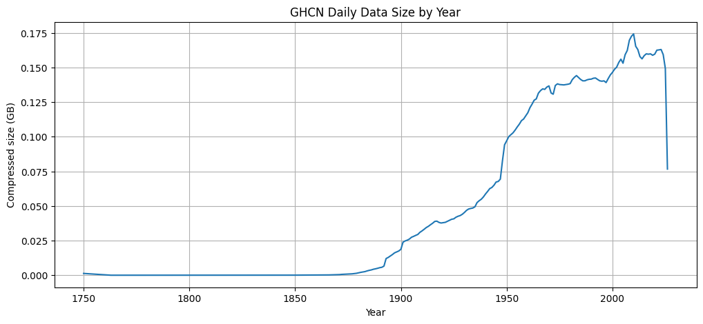

```python
import matplotlib.pyplot as plt

plt.figure(figsize=(12, 5))

plt.plot(
    daily_sizes["year"],
    daily_sizes["size_gb"]
)

plt.xlabel("Year")
plt.ylabel("Compressed size (GB)")
plt.title("GHCN Daily Data Size by Year")

plt.grid(True)
plt.show()
```

# Question 2: Part (a & b)

### Loading stations data

```python
stations_raw = spark.read.text(f"{DATA_PATH}/ghcnd-stations.txt") #stations_raw is distributed # Notice we're not doing .collect() which converts it into a pandas dataframe. Spark has primarily constructed a logical representation of the dataset.
stations_raw.printSchema()
stations_raw.show(5, truncate=False)
```

```
root
 |-- value: string (nullable = true)
```

```
+-------------------------------------------------------------------------------------+
|value                                                                                |
+-------------------------------------------------------------------------------------+
|ACW00011604  17.1167  -61.7833   10.1    ST JOHNS COOLIDGE FLD                       |
|ACW00011647  17.1333  -61.7833   19.2    ST JOHNS                                    |
|AE000041196  25.3330   55.5170   34.0    SHARJAH INTER. AIRP            GSN     41196|
|AEM00041194  25.2550   55.3640   10.4    DUBAI INTL                             41194|
|AEM00041217  24.4330   54.6510   26.8    ABU DHABI INTL                         41217|
+-------------------------------------------------------------------------------------+
only showing top 5 rows
```

```python
# from pyspark.sql.functions import substring # importing the substring function from the library

# stations_id = stations_raw.withColumn(
#     "ID",
#     substring("value", 1, 11)
# )

# stations_id.select("ID").show(10, truncate = False)
```

```
[Stage 1:>                                                          (0 + 1) / 1]
```

```
+-----------+
|ID         |
+-----------+
|ACW00011604|
|ACW00011647|
|AE000041196|
|AEM00041194|
|AEM00041217|
|AEM00041218|
|AF000040930|
|AFM00040938|
|AFM00040948|
|AFM00040990|
+-----------+
only showing top 10 rows
```

```python
# stations_lat = stations_id.withColumn(
#     "LATITUDE",
#     substring("value", 13, 8)
# )
# stations_lat.select("ID","LATITUDE").show(10, truncate = False)
```

```
+-----------+--------+
|ID         |LATITUDE|
+-----------+--------+
|ACW00011604| 17.1167|
|ACW00011647| 17.1333|
|AE000041196| 25.3330|
|AEM00041194| 25.2550|
|AEM00041217| 24.4330|
|AEM00041218| 24.2620|
|AF000040930| 35.3170|
|AFM00040938| 34.2100|
|AFM00040948| 34.5660|
|AFM00040990| 31.5000|
+-----------+--------+
only showing top 10 rows
```

```python
# stations_lon = stations_lat.withColumn(
#     "LONGITUDE",
#     substring("value", 22, 9)
# )
# stations_lon.select("ID","LATITUDE", "LONGITUDE").show(10, truncate = False)

# ## IMPORTANT NOTE:
# # These are narrow transformations: each output row is derived from the corresponding input row. There is no need for Spark to move records between partitions for this operation.
```

```
+-----------+--------+---------+
|ID         |LATITUDE|LONGITUDE|
+-----------+--------+---------+
|ACW00011604| 17.1167| -61.7833|
|ACW00011647| 17.1333| -61.7833|
|AE000041196| 25.3330|  55.5170|
|AEM00041194| 25.2550|  55.3640|
|AEM00041217| 24.4330|  54.6510|
|AEM00041218| 24.2620|  55.6090|
|AF000040930| 35.3170|  69.0170|
|AFM00040938| 34.2100|  62.2280|
|AFM00040948| 34.5660|  69.2120|
|AFM00040990| 31.5000|  65.8500|
+-----------+--------+---------+
only showing top 10 rows
```

```python
# stations_eleva = stations_lon.withColumn(
#     "ELEVATION",
#     substring("value", 32, 7)
# )
# stations_eleva.select("ID", "LATITUDE", "LONGITUDE", "ELEVATION").show(10, truncate = False)

# # Every withColumn() is a transformation. Importantly, these are all row-local transformations:
# # Input row
# #    │
# #    ├── substring ID
# #    ├── substring latitude
# #    ├── substring longitude
# #    └── substring elevation
# #    │
# #    ▼
# # Output row
# # There is no need for Spark to exchange data between executors. So, at this stage: No shuffle is required. This will contrast sharply with what we'll eventually do with:
# # groupBy(...)
# # join(...)
# # where data may need to move between partitions.
```

```
+-----------+--------+---------+---------+
|ID         |LATITUDE|LONGITUDE|ELEVATION|
+-----------+--------+---------+---------+
|ACW00011604| 17.1167| -61.7833|  10.1   |
|ACW00011647| 17.1333| -61.7833|  19.2   |
|AE000041196| 25.3330|  55.5170|  34.0   |
|AEM00041194| 25.2550|  55.3640|  10.4   |
|AEM00041217| 24.4330|  54.6510|  26.8   |
|AEM00041218| 24.2620|  55.6090| 264.9   |
|AF000040930| 35.3170|  69.0170|3366.0   |
|AFM00040938| 34.2100|  62.2280| 977.2   |
|AFM00040948| 34.5660|  69.2120|1791.3   |
|AFM00040990| 31.5000|  65.8500|1010.0   |
+-----------+--------+---------+---------+
only showing top 10 rows
```

```python
# stations_states = stations_eleva.withColumn(
#     "STATES",
#     substring("value", 39, 2)
# )
# stations_states.select("ID", "LATITUDE", "LONGITUDE", "ELEVATION", "STATES").show(10, truncate = False)
```

```
+-----------+--------+---------+---------+------+
|ID         |LATITUDE|LONGITUDE|ELEVATION|STATES|
+-----------+--------+---------+---------+------+
|ACW00011604| 17.1167| -61.7833|  10.1   |      |
|ACW00011647| 17.1333| -61.7833|  19.2   |      |
|AE000041196| 25.3330|  55.5170|  34.0   |      |
|AEM00041194| 25.2550|  55.3640|  10.4   |      |
|AEM00041217| 24.4330|  54.6510|  26.8   |      |
|AEM00041218| 24.2620|  55.6090| 264.9   |      |
|AF000040930| 35.3170|  69.0170|3366.0   |      |
|AFM00040938| 34.2100|  62.2280| 977.2   |      |
|AFM00040948| 34.5660|  69.2120|1791.3   |      |
|AFM00040990| 31.5000|  65.8500|1010.0   |      |
+-----------+--------+---------+---------+------+
only showing top 10 rows
```

```python
# stations_name = stations_states.withColumn(
#     "NAME",
#     substring("value", 42, 30)
# )
# stations_name.select("ID", "LATITUDE", "LONGITUDE", "ELEVATION", "STATES", "NAME").show(10, truncate = False)
```

```
+-----------+--------+---------+---------+------+------------------------------+
|ID         |LATITUDE|LONGITUDE|ELEVATION|STATES|NAME                          |
+-----------+--------+---------+---------+------+------------------------------+
|ACW00011604| 17.1167| -61.7833|  10.1   |      |ST JOHNS COOLIDGE FLD         |
|ACW00011647| 17.1333| -61.7833|  19.2   |      |ST JOHNS                      |
|AE000041196| 25.3330|  55.5170|  34.0   |      |SHARJAH INTER. AIRP           |
|AEM00041194| 25.2550|  55.3640|  10.4   |      |DUBAI INTL                    |
|AEM00041217| 24.4330|  54.6510|  26.8   |      |ABU DHABI INTL                |
|AEM00041218| 24.2620|  55.6090| 264.9   |      |AL AIN INTL                   |
|AF000040930| 35.3170|  69.0170|3366.0   |      |NORTH-SALANG                  |
|AFM00040938| 34.2100|  62.2280| 977.2   |      |HERAT                         |
|AFM00040948| 34.5660|  69.2120|1791.3   |      |KABUL INTL                    |
|AFM00040990| 31.5000|  65.8500|1010.0   |      |KANDAHAR AIRPORT              |
+-----------+--------+---------+---------+------+------------------------------+
only showing top 10 rows
```

```python
# stations_GSN_F = stations_name.withColumn(
#     "GSN FLAG",
#     substring("value", 73, 3)
# )
# stations_GSN_F.select("ID", "LATITUDE", "LONGITUDE", "ELEVATION", "STATES", "NAME", "GSN FLAG").show(20, truncate = False)
```

```
+-----------+--------+---------+---------+------+------------------------------+--------+
|ID         |LATITUDE|LONGITUDE|ELEVATION|STATES|NAME                          |GSN FLAG|
+-----------+--------+---------+---------+------+------------------------------+--------+
|ACW00011604| 17.1167| -61.7833|  10.1   |      |ST JOHNS COOLIDGE FLD         |        |
|ACW00011647| 17.1333| -61.7833|  19.2   |      |ST JOHNS                      |        |
|AE000041196| 25.3330|  55.5170|  34.0   |      |SHARJAH INTER. AIRP           |GSN     |
|AEM00041194| 25.2550|  55.3640|  10.4   |      |DUBAI INTL                    |        |
|AEM00041217| 24.4330|  54.6510|  26.8   |      |ABU DHABI INTL                |        |
|AEM00041218| 24.2620|  55.6090| 264.9   |      |AL AIN INTL                   |        |
|AF000040930| 35.3170|  69.0170|3366.0   |      |NORTH-SALANG                  |GSN     |
|AFM00040938| 34.2100|  62.2280| 977.2   |      |HERAT                         |        |
|AFM00040948| 34.5660|  69.2120|1791.3   |      |KABUL INTL                    |        |
|AFM00040990| 31.5000|  65.8500|1010.0   |      |KANDAHAR AIRPORT              |        |
|AG000060390| 36.7167|   3.2500|  24.0   |      |ALGER-DAR EL BEIDA            |GSN     |
|AG000060590| 30.5667|   2.8667| 397.0   |      |EL-GOLEA                      |GSN     |
|AG000060611| 28.0500|   9.6331| 561.0   |      |IN-AMENAS                     |GSN     |
|AG000060680| 22.8000|   5.4331|1362.0   |      |TAMANRASSET                   |GSN     |
|AGE00135039| 35.7297|   0.6500|  50.0   |      |ORAN-HOPITAL MILITAIRE        |        |
|AGE00147704| 36.9700|   7.7900| 161.0   |      |ANNABA-CAP DE GARDE           |        |
|AGE00147705| 36.7800|   3.0700|  59.0   |      |ALGIERS-VILLE/UNIVERSITE      |        |
|AGE00147706| 36.8000|   3.0300| 344.0   |      |ALGIERS-BOUZAREAH             |        |
|AGE00147707| 36.8000|   3.0400|  38.0   |      |ALGIERS-CAP CAXINE            |        |
|AGE00147708| 36.7200|   4.0500| 222.0   |      |TIZI OUZOU                    |        |
+-----------+--------+---------+---------+------+------------------------------+--------+
only showing top 20 rows
```

```python
# stations_HCN_F = stations_GSN_F.withColumn(
#     "HCN FLAG",
#     substring("value", 77, 3)
# )
# stations_HCN_F.select("ID", "LATITUDE", "LONGITUDE", "ELEVATION", "STATES", "NAME", "GSN FLAG", "HCN FLAG").show(20, truncate = False)

# #Every field is derived from the same original value column.That's worth noticing because, although we're chaining:
# #stations_gsn
# #stations_hcn
# # We're not conceptually creating nine copies of the entire dataset in memory. Spark's lazy execution model allows it to build a logical transformation plan.
# # Later, we'll consolidate these expressions into one clean DataFrame transformation, which is preferable to leaving a long chain of intermediate DataFrames in your final notebook.
```

```
+-----------+--------+---------+---------+------+------------------------------+--------+--------+
|ID         |LATITUDE|LONGITUDE|ELEVATION|STATES|NAME                          |GSN FLAG|HCN FLAG|
+-----------+--------+---------+---------+------+------------------------------+--------+--------+
|ACW00011604| 17.1167| -61.7833|  10.1   |      |ST JOHNS COOLIDGE FLD         |        |        |
|ACW00011647| 17.1333| -61.7833|  19.2   |      |ST JOHNS                      |        |        |
|AE000041196| 25.3330|  55.5170|  34.0   |      |SHARJAH INTER. AIRP           |GSN     |        |
|AEM00041194| 25.2550|  55.3640|  10.4   |      |DUBAI INTL                    |        |        |
|AEM00041217| 24.4330|  54.6510|  26.8   |      |ABU DHABI INTL                |        |        |
|AEM00041218| 24.2620|  55.6090| 264.9   |      |AL AIN INTL                   |        |        |
|AF000040930| 35.3170|  69.0170|3366.0   |      |NORTH-SALANG                  |GSN     |        |
|AFM00040938| 34.2100|  62.2280| 977.2   |      |HERAT                         |        |        |
|AFM00040948| 34.5660|  69.2120|1791.3   |      |KABUL INTL                    |        |        |
|AFM00040990| 31.5000|  65.8500|1010.0   |      |KANDAHAR AIRPORT              |        |        |
|AG000060390| 36.7167|   3.2500|  24.0   |      |ALGER-DAR EL BEIDA            |GSN     |        |
|AG000060590| 30.5667|   2.8667| 397.0   |      |EL-GOLEA                      |GSN     |        |
|AG000060611| 28.0500|   9.6331| 561.0   |      |IN-AMENAS                     |GSN     |        |
|AG000060680| 22.8000|   5.4331|1362.0   |      |TAMANRASSET                   |GSN     |        |
|AGE00135039| 35.7297|   0.6500|  50.0   |      |ORAN-HOPITAL MILITAIRE        |        |        |
|AGE00147704| 36.9700|   7.7900| 161.0   |      |ANNABA-CAP DE GARDE           |        |        |
|AGE00147705| 36.7800|   3.0700|  59.0   |      |ALGIERS-VILLE/UNIVERSITE      |        |        |
|AGE00147706| 36.8000|   3.0300| 344.0   |      |ALGIERS-BOUZAREAH             |        |        |
|AGE00147707| 36.8000|   3.0400|  38.0   |      |ALGIERS-CAP CAXINE            |        |        |
|AGE00147708| 36.7200|   4.0500| 222.0   |      |TIZI OUZOU                    |        |        |
+-----------+--------+---------+---------+------+------------------------------+--------+--------+
only showing top 20 rows
```

```python
# stations_WMO_ID = stations_HCN_F.withColumn(
#     "WMO ID",
#     substring("value", 81, 5)
# )
# stations_WMO_ID.select("ID", "LATITUDE", "LONGITUDE", "ELEVATION", "STATES", "NAME", "GSN FLAG", "HCN FLAG", "WMO ID").show(20, truncate = False)
```

```
+-----------+--------+---------+---------+------+------------------------------+--------+--------+------+
|ID         |LATITUDE|LONGITUDE|ELEVATION|STATES|NAME                          |GSN FLAG|HCN FLAG|WMO ID|
+-----------+--------+---------+---------+------+------------------------------+--------+--------+------+
|ACW00011604| 17.1167| -61.7833|  10.1   |      |ST JOHNS COOLIDGE FLD         |        |        |      |
|ACW00011647| 17.1333| -61.7833|  19.2   |      |ST JOHNS                      |        |        |      |
|AE000041196| 25.3330|  55.5170|  34.0   |      |SHARJAH INTER. AIRP           |GSN     |        |41196 |
|AEM00041194| 25.2550|  55.3640|  10.4   |      |DUBAI INTL                    |        |        |41194 |
|AEM00041217| 24.4330|  54.6510|  26.8   |      |ABU DHABI INTL                |        |        |41217 |
|AEM00041218| 24.2620|  55.6090| 264.9   |      |AL AIN INTL                   |        |        |41218 |
|AF000040930| 35.3170|  69.0170|3366.0   |      |NORTH-SALANG                  |GSN     |        |40930 |
|AFM00040938| 34.2100|  62.2280| 977.2   |      |HERAT                         |        |        |40938 |
|AFM00040948| 34.5660|  69.2120|1791.3   |      |KABUL INTL                    |        |        |40948 |
|AFM00040990| 31.5000|  65.8500|1010.0   |      |KANDAHAR AIRPORT              |        |        |40990 |
|AG000060390| 36.7167|   3.2500|  24.0   |      |ALGER-DAR EL BEIDA            |GSN     |        |60390 |
|AG000060590| 30.5667|   2.8667| 397.0   |      |EL-GOLEA                      |GSN     |        |60590 |
|AG000060611| 28.0500|   9.6331| 561.0   |      |IN-AMENAS                     |GSN     |        |60611 |
|AG000060680| 22.8000|   5.4331|1362.0   |      |TAMANRASSET                   |GSN     |        |60680 |
|AGE00135039| 35.7297|   0.6500|  50.0   |      |ORAN-HOPITAL MILITAIRE        |        |        |      |
|AGE00147704| 36.9700|   7.7900| 161.0   |      |ANNABA-CAP DE GARDE           |        |        |      |
|AGE00147705| 36.7800|   3.0700|  59.0   |      |ALGIERS-VILLE/UNIVERSITE      |        |        |      |
|AGE00147706| 36.8000|   3.0300| 344.0   |      |ALGIERS-BOUZAREAH             |        |        |      |
|AGE00147707| 36.8000|   3.0400|  38.0   |      |ALGIERS-CAP CAXINE            |        |        |      |
|AGE00147708| 36.7200|   4.0500| 222.0   |      |TIZI OUZOU                    |        |        |60395 |
+-----------+--------+---------+---------+------+------------------------------+--------+--------+------+
only showing top 20 rows
```

### Parsing the "stations" dataset

```python
from pyspark.sql.functions import substring # importing the substring function from the library

stations_df = stations_raw.select(
    substring("value", 1, 11).alias("ID"),
    substring("value", 13, 8).alias("LATITUDE"),
    substring("value", 22, 9).alias("LONGITUDE"),
    substring("value", 32, 6).alias("ELEVATION"),
    substring("value", 39, 2).alias("STATE"),
    substring("value", 42, 30).alias("NAME"),
    substring("value", 73, 3).alias("GSN_FLAG"),
    substring("value", 77, 3).alias("HCN_CRN_FLAG"),
    substring("value", 81, 5).alias("WMO_ID")
)


stations_df.show(20, truncate=False)
stations_df.printSchema()
```

```
+-----------+--------+---------+---------+-----+------------------------------+--------+------------+------+
|ID         |LATITUDE|LONGITUDE|ELEVATION|STATE|NAME                          |GSN_FLAG|HCN_CRN_FLAG|WMO_ID|
+-----------+--------+---------+---------+-----+------------------------------+--------+------------+------+
|ACW00011604| 17.1167| -61.7833|  10.1   |     |ST JOHNS COOLIDGE FLD         |        |            |      |
|ACW00011647| 17.1333| -61.7833|  19.2   |     |ST JOHNS                      |        |            |      |
|AE000041196| 25.3330|  55.5170|  34.0   |     |SHARJAH INTER. AIRP           |GSN     |            |41196 |
|AEM00041194| 25.2550|  55.3640|  10.4   |     |DUBAI INTL                    |        |            |41194 |
|AEM00041217| 24.4330|  54.6510|  26.8   |     |ABU DHABI INTL                |        |            |41217 |
|AEM00041218| 24.2620|  55.6090| 264.9   |     |AL AIN INTL                   |        |            |41218 |
|AF000040930| 35.3170|  69.0170|3366.0   |     |NORTH-SALANG                  |GSN     |            |40930 |
|AFM00040938| 34.2100|  62.2280| 977.2   |     |HERAT                         |        |            |40938 |
|AFM00040948| 34.5660|  69.2120|1791.3   |     |KABUL INTL                    |        |            |40948 |
|AFM00040990| 31.5000|  65.8500|1010.0   |     |KANDAHAR AIRPORT              |        |            |40990 |
|AG000060390| 36.7167|   3.2500|  24.0   |     |ALGER-DAR EL BEIDA            |GSN     |            |60390 |
|AG000060590| 30.5667|   2.8667| 397.0   |     |EL-GOLEA                      |GSN     |            |60590 |
|AG000060611| 28.0500|   9.6331| 561.0   |     |IN-AMENAS                     |GSN     |            |60611 |
|AG000060680| 22.8000|   5.4331|1362.0   |     |TAMANRASSET                   |GSN     |            |60680 |
|AGE00135039| 35.7297|   0.6500|  50.0   |     |ORAN-HOPITAL MILITAIRE        |        |            |      |
|AGE00147704| 36.9700|   7.7900| 161.0   |     |ANNABA-CAP DE GARDE           |        |            |      |
|AGE00147705| 36.7800|   3.0700|  59.0   |     |ALGIERS-VILLE/UNIVERSITE      |        |            |      |
|AGE00147706| 36.8000|   3.0300| 344.0   |     |ALGIERS-BOUZAREAH             |        |            |      |
|AGE00147707| 36.8000|   3.0400|  38.0   |     |ALGIERS-CAP CAXINE            |        |            |      |
|AGE00147708| 36.7200|   4.0500| 222.0   |     |TIZI OUZOU                    |        |            |60395 |
+-----------+--------+---------+---------+-----+------------------------------+--------+------------+------+
only showing top 20 rows

root
 |-- ID: string (nullable = true)
 |-- LATITUDE: string (nullable = true)
 |-- LONGITUDE: string (nullable = true)
 |-- ELEVATION: string (nullable = true)
 |-- STATE: string (nullable = true)
 |-- NAME: string (nullable = true)
 |-- GSN_FLAG: string (nullable = true)
 |-- HCN_CRN_FLAG: string (nullable = true)
 |-- WMO_ID: string (nullable = true)
```

### Performing type conversion "LATITUDE", "LONGITUDE" and "ELEVATION"

```python
from pyspark.sql.functions import col

### "LATITUDE" type conversion to "double"

stations_typed = stations_df.withColumn(
    "LATITUDE",
    col("LATITUDE").cast("double")
)

stations_typed.printSchema()
```

```
root
 |-- ID: string (nullable = true)
 |-- LATITUDE: double (nullable = true)
 |-- LONGITUDE: string (nullable = true)
 |-- ELEVATION: string (nullable = true)
 |-- STATE: string (nullable = true)
 |-- NAME: string (nullable = true)
 |-- GSN_FLAG: string (nullable = true)
 |-- HCN_CRN_FLAG: string (nullable = true)
 |-- WMO_ID: string (nullable = true)
```

```python
### "LOGITUDE" type conversion to "double"

stations_typed = stations_typed.withColumn(
    "LONGITUDE",
    col("LONGITUDE").cast("double")
)
stations_typed.printSchema()
```

```
root
 |-- ID: string (nullable = true)
 |-- LATITUDE: double (nullable = true)
 |-- LONGITUDE: double (nullable = true)
 |-- ELEVATION: string (nullable = true)
 |-- STATE: string (nullable = true)
 |-- NAME: string (nullable = true)
 |-- GSN_FLAG: string (nullable = true)
 |-- HCN_CRN_FLAG: string (nullable = true)
 |-- WMO_ID: string (nullable = true)
```

```python
stations_typed = stations_typed.withColumn(
    "ELEVATION",
    col("ELEVATION").cast("double")
)
stations_typed.printSchema()
```

```
root
 |-- ID: string (nullable = true)
 |-- LATITUDE: double (nullable = true)
 |-- LONGITUDE: double (nullable = true)
 |-- ELEVATION: double (nullable = true)
 |-- STATE: string (nullable = true)
 |-- NAME: string (nullable = true)
 |-- GSN_FLAG: string (nullable = true)
 |-- HCN_CRN_FLAG: string (nullable = true)
 |-- WMO_ID: string (nullable = true)
```

### Cleaning white spaces from "STATE"

```python
from pyspark.sql.functions import trim
```

```python
stations_clean = stations_typed.withColumn(
    "STATE",
    trim(col("STATE"))
)

stations_clean.select("ID", "STATE").show(20, truncate=False)
```

```
+-----------+-----+
|ID         |STATE|
+-----------+-----+
|ACW00011604|     |
|ACW00011647|     |
|AE000041196|     |
|AEM00041194|     |
|AEM00041217|     |
|AEM00041218|     |
|AF000040930|     |
|AFM00040938|     |
|AFM00040948|     |
|AFM00040990|     |
|AG000060390|     |
|AG000060590|     |
|AG000060611|     |
|AG000060680|     |
|AGE00135039|     |
|AGE00147704|     |
|AGE00147705|     |
|AGE00147706|     |
|AGE00147707|     |
|AGE00147708|     |
+-----------+-----+
only showing top 20 rows
```

### Adding a "NAME" column

```python
stations_clean = stations_clean.withColumn(
    "NAME",
    trim(col("NAME"))
)

stations_clean.select(
    "ID",
    "NAME"
).show(10, truncate=False)
```

```
[Stage 3:>                                                          (0 + 1) / 1]
```

```
+-----------+---------------------+
|ID         |NAME                 |
+-----------+---------------------+
|ACW00011604|ST JOHNS COOLIDGE FLD|
|ACW00011647|ST JOHNS             |
|AE000041196|SHARJAH INTER. AIRP  |
|AEM00041194|DUBAI INTL           |
|AEM00041217|ABU DHABI INTL       |
|AEM00041218|AL AIN INTL          |
|AF000040930|NORTH-SALANG         |
|AFM00040938|HERAT                |
|AFM00040948|KABUL INTL           |
|AFM00040990|KANDAHAR AIRPORT     |
+-----------+---------------------+
only showing top 10 rows
```

### Adding "GSN_FLAG" column

```python
stations_clean = stations_clean.withColumn(
    "GSN_FLAG",
    trim(col("GSN_FLAG"))
)

stations_clean.select(
    "ID",
    "GSN_FLAG"
).show(20, truncate=False)
```

```
+-----------+--------+
|ID         |GSN_FLAG|
+-----------+--------+
|ACW00011604|        |
|ACW00011647|        |
|AE000041196|GSN     |
|AEM00041194|        |
|AEM00041217|        |
|AEM00041218|        |
|AF000040930|GSN     |
|AFM00040938|        |
|AFM00040948|        |
|AFM00040990|        |
|AG000060390|GSN     |
|AG000060590|GSN     |
|AG000060611|GSN     |
|AG000060680|GSN     |
|AGE00135039|        |
|AGE00147704|        |
|AGE00147705|        |
|AGE00147706|        |
|AGE00147707|        |
|AGE00147708|        |
+-----------+--------+
only showing top 20 rows
```

### Adding "HCN_CRN_FLAG" column

```python
stations_clean = stations_clean.withColumn(
    "HCN_CRN_FLAG",
    trim(col("HCN_CRN_FLAG"))
)

stations_clean.select(
    "ID",
    "HCN_CRN_FLAG"
).show(20, truncate=False)
```

```
+-----------+------------+
|ID         |HCN_CRN_FLAG|
+-----------+------------+
|ACW00011604|            |
|ACW00011647|            |
|AE000041196|            |
|AEM00041194|            |
|AEM00041217|            |
|AEM00041218|            |
|AF000040930|            |
|AFM00040938|            |
|AFM00040948|            |
|AFM00040990|            |
|AG000060390|            |
|AG000060590|            |
|AG000060611|            |
|AG000060680|            |
|AGE00135039|            |
|AGE00147704|            |
|AGE00147705|            |
|AGE00147706|            |
|AGE00147707|            |
|AGE00147708|            |
+-----------+------------+
only showing top 20 rows
```

```python
stations_clean.printSchema()
```

[output not shown]

```python
stations_clean.show(10, truncate=False)
```

[output not shown]

```python
### Counting number of stations
print(f"Total stations count is: {stations_clean.count()}")
```

```
Total stations count is: 132501
```

### Loading "countries" dataset

```python
countries_raw = spark.read.text(
    f"{DATA_PATH}/ghcnd-countries.txt")

countries_raw.show(10, truncate=False)

countries_df = countries_raw.select(
    trim(substring("value", 1, 2)).alias("CODE"),
    trim(substring("value", 4, 61)).alias("NAME")
)

countries_df.printSchema()
countries_df.show(10, truncate=False)
countries_df.count()
```

```
+----------------------------------+
|value                             |
+----------------------------------+
|AC Antigua and Barbuda            |
|AE United Arab Emirates           |
|AF Afghanistan                    |
|AG Algeria                        |
|AJ Azerbaijan                     |
|AL Albania                        |
|AM Armenia                        |
|AO Angola                         |
|AQ American Samoa [United States] |
|AR Argentina                      |
+----------------------------------+
only showing top 10 rows

root
 |-- CODE: string (nullable = true)
 |-- NAME: string (nullable = true)

+----+------------------------------+
|CODE|NAME                          |
+----+------------------------------+
|AC  |Antigua and Barbuda           |
|AE  |United Arab Emirates          |
|AF  |Afghanistan                   |
|AG  |Algeria                       |
|AJ  |Azerbaijan                    |
|AL  |Albania                       |
|AM  |Armenia                       |
|AO  |Angola                        |
|AQ  |American Samoa [United States]|
|AR  |Argentina                     |
+----+------------------------------+
only showing top 10 rows
```

```
219
```

### Loading "states" dataset

```python
states_raw = spark.read.text(
    f"{DATA_PATH}/ghcnd-states.txt"
)

states_df = states_raw.select(
    trim(substring("value", 1, 2)).alias("CODE"),
    trim(substring("value", 4, 47)).alias("NAME")
)

states_df.printSchema()
states_df.show(10, truncate=False)
states_df.count()
```

```
root
 |-- CODE: string (nullable = true)
 |-- NAME: string (nullable = true)

+----+----------------+
|CODE|NAME            |
+----+----------------+
|AB  |ALBERTA         |
|AK  |ALASKA          |
|AL  |ALABAMA         |
|AR  |ARKANSAS        |
|AS  |AMERICAN SAMOA  |
|AZ  |ARIZONA         |
|BC  |BRITISH COLUMBIA|
|CA  |CALIFORNIA      |
|CO  |COLORADO        |
|CT  |CONNECTICUT     |
+----+----------------+
only showing top 10 rows
```

```
74
```

### Loading "inventory" data and performing type conversion

```python
inventory_raw = spark.read.text(
    f"{DATA_PATH}/ghcnd-inventory.txt"
)

inventory_raw.show(10, truncate=False)

inventory_df = inventory_raw.select(
    trim(substring("value", 1, 11)).alias("ID"),
    substring("value", 13, 8).cast("double").alias("LATITUDE"),
    substring("value", 22, 9).cast("double").alias("LONGITUDE"),
    trim(substring("value", 32, 4)).alias("ELEMENT"),
    substring("value", 37, 4).cast("integer").alias("FIRSTYEAR"),
    substring("value", 42, 4).cast("integer").alias("LASTYEAR")
)

inventory_df.printSchema()
inventory_df.show(10, truncate=False)
inventory_df.count()
```

```
+---------------------------------------------+
|value                                        |
+---------------------------------------------+
|ACW00011604  17.1167  -61.7833 TMAX 1949 1949|
|ACW00011604  17.1167  -61.7833 TMIN 1949 1949|
|ACW00011604  17.1167  -61.7833 PRCP 1949 1949|
|ACW00011604  17.1167  -61.7833 SNOW 1949 1949|
|ACW00011604  17.1167  -61.7833 SNWD 1949 1949|
|ACW00011604  17.1167  -61.7833 PGTM 1949 1949|
|ACW00011604  17.1167  -61.7833 WDFG 1949 1949|
|ACW00011604  17.1167  -61.7833 WSFG 1949 1949|
|ACW00011604  17.1167  -61.7833 WT03 1949 1949|
|ACW00011604  17.1167  -61.7833 WT08 1949 1949|
+---------------------------------------------+
only showing top 10 rows

root
 |-- ID: string (nullable = true)
 |-- LATITUDE: double (nullable = true)
 |-- LONGITUDE: double (nullable = true)
 |-- ELEMENT: string (nullable = true)
 |-- FIRSTYEAR: integer (nullable = true)
 |-- LASTYEAR: integer (nullable = true)

+-----------+--------+---------+-------+---------+--------+
|ID         |LATITUDE|LONGITUDE|ELEMENT|FIRSTYEAR|LASTYEAR|
+-----------+--------+---------+-------+---------+--------+
|ACW00011604|17.1167 |-61.7833 |TMAX   |1949     |1949    |
|ACW00011604|17.1167 |-61.7833 |TMIN   |1949     |1949    |
|ACW00011604|17.1167 |-61.7833 |PRCP   |1949     |1949    |
|ACW00011604|17.1167 |-61.7833 |SNOW   |1949     |1949    |
|ACW00011604|17.1167 |-61.7833 |SNWD   |1949     |1949    |
|ACW00011604|17.1167 |-61.7833 |PGTM   |1949     |1949    |
|ACW00011604|17.1167 |-61.7833 |WDFG   |1949     |1949    |
|ACW00011604|17.1167 |-61.7833 |WSFG   |1949     |1949    |
|ACW00011604|17.1167 |-61.7833 |WT03   |1949     |1949    |
|ACW00011604|17.1167 |-61.7833 |WT08   |1949     |1949    |
+-----------+--------+---------+-------+---------+--------+
only showing top 10 rows
```

```
782417
```

# Question 2: Part (c)

### Defining "daily" schema

```python
from pyspark.sql.types import (
    StructType,
    StructField,
    StringType,
    DateType,
    DoubleType
)


daily_schema = StructType([
    StructField("ID", StringType(), True),
    StructField("DATE", DateType(), True),
    StructField("ELEMENT", StringType(), True),
    StructField("VALUE", DoubleType(), True),
    StructField("MEASUREMENT_FLAG", StringType(), True),
    StructField("QUALITY_FLAG", StringType(), True),
    StructField("SOURCE_FLAG", StringType(), True),
    StructField("OBSERVATION_TIME", StringType(), True)
])

daily_schema.simpleString()

# using OBSERVATION_TIME in Spark is sensible because Spark column names are much easier to work with without spaces.
```

```
'struct<ID:string,DATE:date,ELEMENT:string,VALUE:double,MEASUREMENT_FLAG:string,QUALITY_FLAG:string,SOURCE_FLAG:string,OBSERVATION_TIME:string>'
```

# Question 2: Part (d)

**Distributed-data engineering principle:**

Don't read a much larger dataset than necessary when you're only testing your schema.

```python
!hdfs dfs -ls "$DATA_PATH/daily" | tail
```

```
-rwxrwxrwx   1  171303217 2026-08-05 14:37 wasbs://campus-data@madsstorage002.blob.core.windows.net/ghcnd/daily/2017.csv.gz
-rwxrwxrwx   1  171556554 2026-08-05 14:37 wasbs://campus-data@madsstorage002.blob.core.windows.net/ghcnd/daily/2018.csv.gz
-rwxrwxrwx   1  170465024 2026-08-05 14:36 wasbs://campus-data@madsstorage002.blob.core.windows.net/ghcnd/daily/2019.csv.gz
-rwxrwxrwx   1  171345688 2026-08-05 14:36 wasbs://campus-data@madsstorage002.blob.core.windows.net/ghcnd/daily/2020.csv.gz
-rwxrwxrwx   1  174411559 2026-08-05 14:37 wasbs://campus-data@madsstorage002.blob.core.windows.net/ghcnd/daily/2021.csv.gz
-rwxrwxrwx   1  174626384 2026-08-05 14:36 wasbs://campus-data@madsstorage002.blob.core.windows.net/ghcnd/daily/2022.csv.gz
-rwxrwxrwx   1  174947481 2026-08-05 14:36 wasbs://campus-data@madsstorage002.blob.core.windows.net/ghcnd/daily/2023.csv.gz
-rwxrwxrwx   1  170976636 2026-08-05 14:36 wasbs://campus-data@madsstorage002.blob.core.windows.net/ghcnd/daily/2024.csv.gz
-rwxrwxrwx   1  160283428 2026-08-05 14:36 wasbs://campus-data@madsstorage002.blob.core.windows.net/ghcnd/daily/2025.csv.gz
-rwxrwxrwx   1   82252938 2026-08-05 14:37 wasbs://campus-data@madsstorage002.blob.core.windows.net/ghcnd/daily/2026.csv.gz
```

### Loading "daily_2026" with "DATE" column as "date" type

```python
daily_2026 = spark.read.csv(
    f"{DATA_PATH}/daily/2026.csv.gz",
    schema = daily_schema,
    sep = ",",
    nullValue = ""
)

daily_2026.printSchema()
daily_2026.show(10, truncate=False)
daily_2026.select("DATE").show(10, truncate=False)
```

```
root
 |-- ID: string (nullable = true)
 |-- DATE: date (nullable = true)
 |-- ELEMENT: string (nullable = true)
 |-- VALUE: double (nullable = true)
 |-- MEASUREMENT_FLAG: string (nullable = true)
 |-- QUALITY_FLAG: string (nullable = true)
 |-- SOURCE_FLAG: string (nullable = true)
 |-- OBSERVATION_TIME: string (nullable = true)

+-----------+----+-------+-----+----------------+------------+-----------+----------------+
|ID         |DATE|ELEMENT|VALUE|MEASUREMENT_FLAG|QUALITY_FLAG|SOURCE_FLAG|OBSERVATION_TIME|
+-----------+----+-------+-----+----------------+------------+-----------+----------------+
|US1ALJF0007|NULL|PRCP   |0.0  |NULL            |NULL        |N          |0800            |
|US1ALJF0007|NULL|SNOW   |0.0  |NULL            |NULL        |N          |0800            |
|US1ALJF0025|NULL|PRCP   |0.0  |NULL            |NULL        |N          |0700            |
|US1ALJF0025|NULL|SNOW   |0.0  |NULL            |NULL        |N          |0700            |
|US1ALJF0047|NULL|PRCP   |0.0  |NULL            |NULL        |N          |0700            |
|US1ALJF0047|NULL|SNOW   |0.0  |NULL            |NULL        |N          |0700            |
|US1ALJF0054|NULL|PRCP   |0.0  |NULL            |NULL        |N          |0630            |
|US1ALJF0054|NULL|SNOW   |0.0  |NULL            |NULL        |N          |0630            |
|US1ALJF0069|NULL|PRCP   |0.0  |NULL            |NULL        |N          |0700            |
|US1ALJF0069|NULL|SNOW   |0.0  |NULL            |NULL        |N          |0700            |
+-----------+----+-------+-----+----------------+------------+-----------+----------------+
only showing top 10 rows

+----+
|DATE|
+----+
|NULL|
|NULL|
|NULL|
|NULL|
|NULL|
|NULL|
|NULL|
|NULL|
|NULL|
|NULL|
+----+
only showing top 10 rows
```

**Observed result:**

The important finding: DATE became NULL This is the key issue Q2(d) wants you to identify.

**Reason**

The source date is stored as:

```
YYYYMMDD
```

For example, conceptually:

```
20260101
```

but we told Spark:

```
StructField("DATE", DateType(), True)
```

Spark's CSV reader did not interpret that representation as a Spark DateType, so the values became:

```
NULL
```

This is an excellent example of schema ≠ successful parsing

We specified:

```
DATE → DateType
```

and Spark accepted the schema.

But:

**accepted schema ≠ successfully parsed data**

That's an important data-engineering lesson I have learned.

**Next decision:** Load DATE as StringType and explicitly convert it using the source format.

### Loading revised "daily_2026" schma with "DATE" column as "StringType()"

```python
daily_schema_raw_date = StructType([
    StructField("ID", StringType(), True),
    StructField("DATE", StringType(), True),
    StructField("ELEMENT", StringType(), True),
    StructField("VALUE", DoubleType(), True),
    StructField("MEASUREMENT_FLAG", StringType(), True),
    StructField("QUALITY_FLAG", StringType(), True),
    StructField("SOURCE_FLAG", StringType(), True),
    StructField("OBSERVATION_TIME", StringType(), True)
])

daily_2026_raw = spark.read.csv(
    f"{DATA_PATH}/daily/2026.csv.gz",
    schema=daily_schema_raw_date,
    sep=",",
    nullValue=""
)

daily_2026_raw.select(
    "ID",
    "DATE",
    "ELEMENT",
    "VALUE",
    "OBSERVATION_TIME"
).show(10, truncate=False)
```

```
+-----------+--------+-------+-----+----------------+
|ID         |DATE    |ELEMENT|VALUE|OBSERVATION_TIME|
+-----------+--------+-------+-----+----------------+
|US1ALJF0007|20260101|PRCP   |0.0  |0800            |
|US1ALJF0007|20260101|SNOW   |0.0  |0800            |
|US1ALJF0025|20260101|PRCP   |0.0  |0700            |
|US1ALJF0025|20260101|SNOW   |0.0  |0700            |
|US1ALJF0047|20260101|PRCP   |0.0  |0700            |
|US1ALJF0047|20260101|SNOW   |0.0  |0700            |
|US1ALJF0054|20260101|PRCP   |0.0  |0630            |
|US1ALJF0054|20260101|SNOW   |0.0  |0630            |
|US1ALJF0069|20260101|PRCP   |0.0  |0700            |
|US1ALJF0069|20260101|SNOW   |0.0  |0700            |
+-----------+--------+-------+-----+----------------+
only showing top 10 rows
```

What I am trying to achieve is:

Architecturally:

```
         HDFS
          │
          ▼
   CSV distributed read
          │
          ▼
   daily_2026_raw
          │
          ▼
   DATE = string
          │
          ▼
   explicit parsing
          │
          ▼
   DATE = date
```

And importantly, the CSV read itself is distributed across Spark's partitions. I am not collecting the 2026 dataset into Python.

### Converting "DATE" column from Spark StringType() to Spark "date" type

```python
from pyspark.sql.functions import to_date
```

```python
daily_2026 = daily_2026_raw.withColumn(
    "DATE",
    to_date(col("DATE"), "yyyyMMdd")
)

daily_2026.printSchema()

daily_2026.select(
    "ID",
    "DATE",
    "ELEMENT",
    "VALUE",
    "OBSERVATION_TIME"
).show(10, truncate=False)

daily_2026.count()

# This is preferable to relying on Spark's default parser because we explicitly tell Spark what the source format is.
```

```
root
 |-- ID: string (nullable = true)
 |-- DATE: date (nullable = true)
 |-- ELEMENT: string (nullable = true)
 |-- VALUE: double (nullable = true)
 |-- MEASUREMENT_FLAG: string (nullable = true)
 |-- QUALITY_FLAG: string (nullable = true)
 |-- SOURCE_FLAG: string (nullable = true)
 |-- OBSERVATION_TIME: string (nullable = true)

+-----------+----------+-------+-----+----------------+
|ID         |DATE      |ELEMENT|VALUE|OBSERVATION_TIME|
+-----------+----------+-------+-----+----------------+
|US1ALJF0007|2026-01-01|PRCP   |0.0  |0800            |
|US1ALJF0007|2026-01-01|SNOW   |0.0  |0800            |
|US1ALJF0025|2026-01-01|PRCP   |0.0  |0700            |
|US1ALJF0025|2026-01-01|SNOW   |0.0  |0700            |
|US1ALJF0047|2026-01-01|PRCP   |0.0  |0700            |
|US1ALJF0047|2026-01-01|SNOW   |0.0  |0700            |
|US1ALJF0054|2026-01-01|PRCP   |0.0  |0630            |
|US1ALJF0054|2026-01-01|SNOW   |0.0  |0630            |
|US1ALJF0069|2026-01-01|PRCP   |0.0  |0700            |
|US1ALJF0069|2026-01-01|SNOW   |0.0  |0700            |
+-----------+----------+-------+-----+----------------+
only showing top 10 rows
```

```
17988944
```

**Report Point**

The source DATE field uses YYYYMMDD, which was not correctly interpreted when directly loaded as Spark date type. Loading it as a string first and explicitly parsing it with the known yyyyMMdd format preserves the source value and produces the desired Spark **"date"** type.

**Useful Performance Principle** Learned:

Don't perform an expensive transformation when the current question doesn't require it.

# Question 2: Part(e)

### Loading all daily data

```python
daily_all_raw = spark.read.csv(
    f"{DATA_PATH}/daily/*.csv.gz",
    schema=daily_schema_raw_date,
    sep=",",
    nullValue=""
)
```

### Calculating number of records in all "daily"

```python
daily_all_raw.count()
```

```
3190506382
```

What we have established:

| Dataset | Rows |
| --- | --- |
| `stations` | 132,501 |
| `countries` | 219 |
| `states` | 74 |
| `inventory` | 782,417 |
| `daily` — 2026 | 17,988,944 |
| `daily` — all years | **3,190,506,382** |

Our "daily" dataset is roughly 3.19 billion records. A very important distributed-computing observation is that when we ran:

daily_all_raw.count()

Spark did not put 3.19 billion rows into the driver's memory.

Instead:

```
                HDFS
                 │
          daily/*.csv.gz
                 │
      ┌──────────┼──────────┐
      ▼          ▼          ▼
  Partition   Partition   Partition
      │          │          │
      ▼          ▼          ▼
  Executor    Executor    Executor
      │          │          │
      └──────────┼──────────┘
                 ▼
          partial counts
                 │
                 ▼
              Driver
                 │
                 ▼
         3,190,506,382
```

**count() only needs to return one integer to the driver**

That's fundamentally different from:

daily_all_raw.collect()

which would attempt to bring the entire result to the driver and is explicitly inappropriate here.

Memory question — think about this yourself

The assignment asks:

Does the amount of driver and executor memory matter? How does the size of daily compare to your executor memory?

Don't answer this by simply saying "daily is too big for memory."

The more important concept is:

Spark does not require the entire dataset to fit in one executor's memory.

Instead:

```
    3.19 billion rows
    ↓
    split across partitions
    ↓
    processed by executors
    ↓
    partial results
    ↓
    combined
```

That's one of the fundamental reasons distributed computing exists.

**However, executor memory still matters because each executor must have enough memory for the partitions and intermediate data it is processing.**

We are using only 2 executors with 1 core per executor at this stage, and we will later increase the computing resources when necessary.

# Question 3: Part (a)

```python
stations_clean.show(20, truncate=False)
```

```
+-----------+--------+---------+---------+-----+------------------------+--------+------------+------+
|ID         |LATITUDE|LONGITUDE|ELEVATION|STATE|NAME                    |GSN_FLAG|HCN_CRN_FLAG|WMO_ID|
+-----------+--------+---------+---------+-----+------------------------+--------+------------+------+
|ACW00011604|17.1167 |-61.7833 |10.1     |     |ST JOHNS COOLIDGE FLD   |        |            |      |
|ACW00011647|17.1333 |-61.7833 |19.2     |     |ST JOHNS                |        |            |      |
|AE000041196|25.333  |55.517   |34.0     |     |SHARJAH INTER. AIRP     |GSN     |            |41196 |
|AEM00041194|25.255  |55.364   |10.4     |     |DUBAI INTL              |        |            |41194 |
|AEM00041217|24.433  |54.651   |26.8     |     |ABU DHABI INTL          |        |            |41217 |
|AEM00041218|24.262  |55.609   |264.9    |     |AL AIN INTL             |        |            |41218 |
|AF000040930|35.317  |69.017   |3366.0   |     |NORTH-SALANG            |GSN     |            |40930 |
|AFM00040938|34.21   |62.228   |977.2    |     |HERAT                   |        |            |40938 |
|AFM00040948|34.566  |69.212   |1791.3   |     |KABUL INTL              |        |            |40948 |
|AFM00040990|31.5    |65.85    |1010.0   |     |KANDAHAR AIRPORT        |        |            |40990 |
|AG000060390|36.7167 |3.25     |24.0     |     |ALGER-DAR EL BEIDA      |GSN     |            |60390 |
|AG000060590|30.5667 |2.8667   |397.0    |     |EL-GOLEA                |GSN     |            |60590 |
|AG000060611|28.05   |9.6331   |561.0    |     |IN-AMENAS               |GSN     |            |60611 |
|AG000060680|22.8    |5.4331   |1362.0   |     |TAMANRASSET             |GSN     |            |60680 |
|AGE00135039|35.7297 |0.65     |50.0     |     |ORAN-HOPITAL MILITAIRE  |        |            |      |
|AGE00147704|36.97   |7.79     |161.0    |     |ANNABA-CAP DE GARDE     |        |            |      |
|AGE00147705|36.78   |3.07     |59.0     |     |ALGIERS-VILLE/UNIVERSITE|        |            |      |
|AGE00147706|36.8    |3.03     |344.0    |     |ALGIERS-BOUZAREAH       |        |            |      |
|AGE00147707|36.8    |3.04     |38.0     |     |ALGIERS-CAP CAXINE      |        |            |      |
|AGE00147708|36.72   |4.05     |222.0    |     |TIZI OUZOU              |        |            |60395 |
+-----------+--------+---------+---------+-----+------------------------+--------+------------+------+
only showing top 20 rows
```

### Creating "COUNTRY_CODE" column from from "stations_clean"

```python
stations_enriched = stations_clean.withColumn(
    "COUNTRY_CODE",
    substring(col("ID"),1,2)
)
stations_enriched.show(20, truncate = False)
```

```
+-----------+--------+---------+---------+-----+------------------------+--------+------------+------+------------+
|ID         |LATITUDE|LONGITUDE|ELEVATION|STATE|NAME                    |GSN_FLAG|HCN_CRN_FLAG|WMO_ID|COUNTRY_CODE|
+-----------+--------+---------+---------+-----+------------------------+--------+------------+------+------------+
|ACW00011604|17.1167 |-61.7833 |  10.1   |     |ST JOHNS COOLIDGE FLD   |        |            |      |AC          |
|ACW00011647|17.1333 |-61.7833 |  19.2   |     |ST JOHNS                |        |            |      |AC          |
|AE000041196|25.333  |55.517   |  34.0   |     |SHARJAH INTER. AIRP     |GSN     |            |41196 |AE          |
|AEM00041194|25.255  |55.364   |  10.4   |     |DUBAI INTL              |        |            |41194 |AE          |
|AEM00041217|24.433  |54.651   |  26.8   |     |ABU DHABI INTL          |        |            |41217 |AE          |
|AEM00041218|24.262  |55.609   | 264.9   |     |AL AIN INTL             |        |            |41218 |AE          |
|AF000040930|35.317  |69.017   |3366.0   |     |NORTH-SALANG            |GSN     |            |40930 |AF          |
|AFM00040938|34.21   |62.228   | 977.2   |     |HERAT                   |        |            |40938 |AF          |
|AFM00040948|34.566  |69.212   |1791.3   |     |KABUL INTL              |        |            |40948 |AF          |
|AFM00040990|31.5    |65.85    |1010.0   |     |KANDAHAR AIRPORT        |        |            |40990 |AF          |
|AG000060390|36.7167 |3.25     |  24.0   |     |ALGER-DAR EL BEIDA      |GSN     |            |60390 |AG          |
|AG000060590|30.5667 |2.8667   | 397.0   |     |EL-GOLEA                |GSN     |            |60590 |AG          |
|AG000060611|28.05   |9.6331   | 561.0   |     |IN-AMENAS               |GSN     |            |60611 |AG          |
|AG000060680|22.8    |5.4331   |1362.0   |     |TAMANRASSET             |GSN     |            |60680 |AG          |
|AGE00135039|35.7297 |0.65     |  50.0   |     |ORAN-HOPITAL MILITAIRE  |        |            |      |AG          |
|AGE00147704|36.97   |7.79     | 161.0   |     |ANNABA-CAP DE GARDE     |        |            |      |AG          |
|AGE00147705|36.78   |3.07     |  59.0   |     |ALGIERS-VILLE/UNIVERSITE|        |            |      |AG          |
|AGE00147706|36.8    |3.03     | 344.0   |     |ALGIERS-BOUZAREAH       |        |            |      |AG          |
|AGE00147707|36.8    |3.04     |  38.0   |     |ALGIERS-CAP CAXINE      |        |            |      |AG          |
|AGE00147708|36.72   |4.05     | 222.0   |     |TIZI OUZOU              |        |            |60395 |AG          |
+-----------+--------+---------+---------+-----+------------------------+--------+------------+------+------------+
only showing top 20 rows
```

# Question 3: Part (b)

```python
countries_df.show(20, truncate = False)
```

```
+----+------------------------------+
|CODE|NAME                          |
+----+------------------------------+
|AC  |Antigua and Barbuda           |
|AE  |United Arab Emirates          |
|AF  |Afghanistan                   |
|AG  |Algeria                       |
|AJ  |Azerbaijan                    |
|AL  |Albania                       |
|AM  |Armenia                       |
|AO  |Angola                        |
|AQ  |American Samoa [United States]|
|AR  |Argentina                     |
|AS  |Australia                     |
|AU  |Austria                       |
|AY  |Antarctica                    |
|BA  |Bahrain                       |
|BB  |Barbados                      |
|BC  |Botswana                      |
|BD  |Bermuda [United Kingdom]      |
|BE  |Belgium                       |
|BF  |Bahamas, The                  |
|BG  |Bangladesh                    |
+----+------------------------------+
only showing top 20 rows
```

### Joining "stations" and "countries"

```python
stations_country = stations_enriched.join(
    countries_df,
    stations_enriched["COUNTRY_CODE"] == countries_df["CODE"],
    "left"
)
stations_country.printSchema()

stations_country.select(
    "ID",
    "COUNTRY_CODE",
    "STATE",
    countries_df["NAME"].alias("COUNTRY_NAME")
).show(10, truncate=False)

print(f"The stations_country still has the records: {stations_country.count()}")
```

```
root
 |-- ID: string (nullable = true)
 |-- LATITUDE: double (nullable = true)
 |-- LONGITUDE: double (nullable = true)
 |-- ELEVATION: string (nullable = true)
 |-- STATE: string (nullable = true)
 |-- NAME: string (nullable = true)
 |-- GSN_FLAG: string (nullable = true)
 |-- HCN_CRN_FLAG: string (nullable = true)
 |-- WMO_ID: string (nullable = true)
 |-- COUNTRY_CODE: string (nullable = true)
 |-- CODE: string (nullable = true)
 |-- NAME: string (nullable = true)

+-----------+------------+-----+--------------------+
|ID         |COUNTRY_CODE|STATE|COUNTRY_NAME        |
+-----------+------------+-----+--------------------+
|ACW00011604|AC          |     |Antigua and Barbuda |
|ACW00011647|AC          |     |Antigua and Barbuda |
|AE000041196|AE          |     |United Arab Emirates|
|AEM00041194|AE          |     |United Arab Emirates|
|AEM00041217|AE          |     |United Arab Emirates|
|AEM00041218|AE          |     |United Arab Emirates|
|AF000040930|AF          |     |Afghanistan         |
|AFM00040938|AF          |     |Afghanistan         |
|AFM00040948|AF          |     |Afghanistan         |
|AFM00040990|AF          |     |Afghanistan         |
+-----------+------------+-----+--------------------+
only showing top 10 rows

The stations_country still has the records: 132501
```

# Question 3: Part (c)

```python
# states_df.show(20, truncate = False)
# stations_country.where(col("COUNTRY_CODE") == "US").show(100, truncate = False)
```

### Joining "stations" and "states"

```python
stations_state = stations_country.join(
    states_df,
    stations_country["STATE"] == states_df["CODE"],
    "left"
)

stations_state.select(
    "ID",
    "STATE",
    states_df["NAME"].alias("STATE_NAME")
).where(col("COUNTRY_CODE") == "US").show(10, truncate=False)

stations_state.count()
```

```
+-----------+-----+------------+
|ID         |STATE|STATE_NAME  |
+-----------+-----+------------+
|US009052008|SD   |SOUTH DAKOTA|
|US10RMHS145|CO   |COLORADO    |
|US10adam001|NE   |NEBRASKA    |
|US10adam002|NE   |NEBRASKA    |
|US10adam003|NE   |NEBRASKA    |
|US10adam004|NE   |NEBRASKA    |
|US10adam006|NE   |NEBRASKA    |
|US10adam007|NE   |NEBRASKA    |
|US10adam008|NE   |NEBRASKA    |
|US10adam010|NE   |NEBRASKA    |
+-----------+-----+------------+
only showing top 10 rows
```

```
132501
```

# Question 3: Part (d)

```python
inventory_df.show(20, truncate = False)
# inventory_df.select("ELEMENT").distinct().show()
# inventory_df.select(F.count_distinct("ELEMENT")).show()
```

```
+-----------+--------+---------+-------+---------+--------+
|ID         |LATITUDE|LONGITUDE|ELEMENT|FIRSTYEAR|LASTYEAR|
+-----------+--------+---------+-------+---------+--------+
|ACW00011604|17.1167 |-61.7833 |TMAX   |1949     |1949    |
|ACW00011604|17.1167 |-61.7833 |TMIN   |1949     |1949    |
|ACW00011604|17.1167 |-61.7833 |PRCP   |1949     |1949    |
|ACW00011604|17.1167 |-61.7833 |SNOW   |1949     |1949    |
|ACW00011604|17.1167 |-61.7833 |SNWD   |1949     |1949    |
|ACW00011604|17.1167 |-61.7833 |PGTM   |1949     |1949    |
|ACW00011604|17.1167 |-61.7833 |WDFG   |1949     |1949    |
|ACW00011604|17.1167 |-61.7833 |WSFG   |1949     |1949    |
|ACW00011604|17.1167 |-61.7833 |WT03   |1949     |1949    |
|ACW00011604|17.1167 |-61.7833 |WT08   |1949     |1949    |
|ACW00011604|17.1167 |-61.7833 |WT16   |1949     |1949    |
|ACW00011647|17.1333 |-61.7833 |TMAX   |1961     |2026    |
|ACW00011647|17.1333 |-61.7833 |TMIN   |1961     |2026    |
|ACW00011647|17.1333 |-61.7833 |PRCP   |1957     |1970    |
|ACW00011647|17.1333 |-61.7833 |SNOW   |1957     |1970    |
|ACW00011647|17.1333 |-61.7833 |SNWD   |1957     |1970    |
|ACW00011647|17.1333 |-61.7833 |TAVG   |2025     |2026    |
|ACW00011647|17.1333 |-61.7833 |WT03   |1961     |1961    |
|ACW00011647|17.1333 |-61.7833 |WT16   |1961     |1966    |
|AE000041196|25.333  |55.517   |TMAX   |1944     |2025    |
+-----------+--------+---------+-------+---------+--------+
only showing top 20 rows
```

### Detrmining first and last year active

```python
from pyspark.sql.functions import collect_set, min, max

inventory_summary = inventory_df.groupBy("ID").agg(
    collect_set("ELEMENT").alias("ELEMENTS"),
    min("FIRSTYEAR").alias("FIRST_YEAR"),
    max("LASTYEAR").alias("LAST_YEAR")
)

inventory_summary.printSchema()

inventory_summary.show(10, truncate=False)
```

```
root
 |-- ID: string (nullable = true)
 |-- ELEMENTS: array (nullable = false)
 |    |-- element: string (containsNull = false)
 |-- FIRST_YEAR: integer (nullable = true)
 |-- LAST_YEAR: integer (nullable = true)
```

```
[Stage 75:=============================>                            (1 + 1) / 2]
```

```
+-----------+------------------------------+----------+---------+
|ID         |ELEMENTS                      |FIRST_YEAR|LAST_YEAR|
+-----------+------------------------------+----------+---------+
|AE000041196|[TMAX, TMIN, PRCP, TAVG]      |1944      |2025     |
|AEM00041217|[TMAX, TMIN, PRCP, TAVG]      |1983      |2025     |
|AEM00041218|[TMAX, TMIN, PRCP, TAVG]      |1994      |2025     |
|AF000040930|[TMAX, TMIN, PRCP, SNWD, TAVG]|1973      |1992     |
|AFM00040990|[TMAX, TMIN, PRCP, SNWD, TAVG]|1973      |2020     |
|AG000060680|[TMAX, TMIN, PRCP, TAVG]      |1940      |2004     |
|AGE00147704|[TMAX, TMIN, PRCP]            |1909      |1937     |
|AGE00147708|[TMAX, TMIN, PRCP, SNWD, TAVG]|1879      |2025     |
|AGE00147710|[TMAX, TMIN, PRCP, TAVG]      |1909      |2025     |
|AGE00147712|[TMAX, TMIN, PRCP]            |1879      |1938     |
+-----------+------------------------------+----------+---------+
only showing top 10 rows
```

Conceptually,

```
             inventory_df
                  │
         782,417 records
                  │
          ┌───────┴───────┐
          ▼               ▼
      Executor 1      Executor 2
          │               │
          └───────┬───────┘
                  │
                SHUFFLE
                  │
      records grouped by ID
                  │
                  ▼
          aggregation
          /    |     \
         /     |      \
  collect_set min     max
         \     |      /
          \    |     /
           ▼   ▼    ▼
      inventory_summary
```

### Adding "ACTIVE_2026" column

```python
inventory_summary = inventory_summary.withColumn(
    "ACTIVE_2026",
    col("LAST_YEAR") >= 2026
)
```

```python
inventory_summary.select(
    "ID",
    "FIRST_YEAR",
    "LAST_YEAR",
    "ACTIVE_2026"
).show(20, truncate=False)
```

```
[Stage 78:=============================>                            (1 + 1) / 2]
```

```
+-----------+----------+---------+-----------+
|ID         |FIRST_YEAR|LAST_YEAR|ACTIVE_2026|
+-----------+----------+---------+-----------+
|US1WVHN0003|2016      |2018     |false      |
|US1WVHS0006|2013      |2017     |false      |
|US1WVHS0009|2017      |2018     |false      |
|US1WVJC0003|2009      |2026     |true       |
|US1WVJF0003|2008      |2021     |false      |
|US1WVKN0001|1998      |2026     |true       |
|US1WVKN0027|2017      |2020     |false      |
|US1WVKN0043|2022      |2026     |true       |
|US1WVLW0002|2012      |2020     |false      |
|US1WVMH0002|2009      |2012     |false      |
|US1WVNC0004|2013      |2026     |true       |
|US1WVPR0003|2009      |2011     |false      |
|US1WVPR0010|2018      |2024     |false      |
|US1WVPR0020|2020      |2026     |true       |
|US1WVPR0021|2021      |2021     |false      |
|US1WVPT0011|2018      |2026     |true       |
|US1WVPT0015|2025      |2026     |true       |
|US1WVRL0006|2013      |2024     |false      |
|US1WVWD0011|2013      |2021     |false      |
|US1WYAB0007|2004      |2006     |false      |
+-----------+----------+---------+-----------+
only showing top 20 rows
```

### Calculating active stations in 2026

```python
active_2026 = inventory_summary.filter(
    col("ACTIVE_2026")
).count()

print(f"Active station is 2026 are: {active_2026}")
```

```
[Stage 81:>                                                         (0 + 2) / 2]
```

```
Active station is 2026 are: 37422
```

### Calculating "CORE_ELEMENT_COUNT" and "OTHER_ELEMENT_COUNT"

```python
from pyspark.sql.functions import array, array_intersect, size, lit
from pyspark.sql.functions import array_contains
```

```python
core_elements = array(
    lit("TMIN"),
    lit("TMAX"),
    lit("PRCP"),
    lit("SNOW"),
    lit("SNWD")
)

inventory_summary = inventory_summary.withColumn(
    "CORE_ELEMENT_COUNT",
    size(array_intersect(col("ELEMENTS"), core_elements))
).withColumn(
    "OTHER_ELEMENT_COUNT",
    size(col("ELEMENTS")) - col("CORE_ELEMENT_COUNT")
)

inventory_summary.select(
    "ID",
    "ELEMENTS",
    "CORE_ELEMENT_COUNT",
    "OTHER_ELEMENT_COUNT"
).show(20, truncate=False)
```

```
[Stage 87:>                                                         (0 + 2) / 2]
```

```
+-----------+------------------------------+------------------+-------------------+
|ID         |ELEMENTS                      |CORE_ELEMENT_COUNT|OTHER_ELEMENT_COUNT|
+-----------+------------------------------+------------------+-------------------+
|AE000041196|[TMAX, TMIN, PRCP, TAVG]      |3                 |1                  |
|AEM00041217|[TMAX, TMIN, PRCP, TAVG]      |3                 |1                  |
|AEM00041218|[TMAX, TMIN, PRCP, TAVG]      |3                 |1                  |
|AF000040930|[TMAX, TMIN, PRCP, SNWD, TAVG]|4                 |1                  |
|AFM00040990|[TMAX, TMIN, PRCP, SNWD, TAVG]|4                 |1                  |
|AG000060680|[TMAX, TMIN, PRCP, TAVG]      |3                 |1                  |
|AGE00147704|[TMAX, TMIN, PRCP]            |3                 |0                  |
|AGE00147708|[TMAX, TMIN, PRCP, SNWD, TAVG]|4                 |1                  |
|AGE00147710|[TMAX, TMIN, PRCP, TAVG]      |3                 |1                  |
|AGE00147712|[TMAX, TMIN, PRCP]            |3                 |0                  |
|AGE00147713|[TMAX, TMIN, PRCP]            |3                 |0                  |
|AGE00147714|[TMAX, TMIN, PRCP]            |3                 |0                  |
|AGE00147715|[TMAX, TMIN, PRCP]            |3                 |0                  |
|AGE00147717|[TMAX, TMIN, PRCP]            |3                 |0                  |
|AGE00147718|[TMAX, TMIN, PRCP, TAVG]      |3                 |1                  |
|AGE00147719|[TMAX, TMIN, PRCP, TAVG]      |3                 |1                  |
|AGE00147794|[TMAX, TMIN]                  |2                 |0                  |
|AGM00060360|[TMAX, TMIN, PRCP, TAVG]      |3                 |1                  |
|AGM00060367|[TMAX, TMIN, PRCP, TAVG]      |3                 |1                  |
|AGM00060402|[TMAX, TMIN, PRCP, SNWD, TAVG]|4                 |1                  |
+-----------+------------------------------+------------------+-------------------+
only showing top 20 rows
```

### Station which collected all 5 core elements

```python
inventory_summary.filter(
    col("CORE_ELEMENT_COUNT") == 5
).count()
```

```
20505
```

### Stations which collected only "PRCP"

```python
inventory_summary.filter(
    (array_contains(col("ELEMENTS"), "PRCP")) &
    (size(col("ELEMENTS")) == 1)
).count()
```

```
16189
```

**Summary**

```
37,422  → active in 2026
20,505  → all five core elements
16,189  → only PRCP
```

```
Q3(d) / inventory work completed

Some findings:

132,501 total stations
132,437 stations with inventory
64 stations without inventory
0 inventory records belonging to unknown station IDs
37,422 stations active in 2026 based on inventory
20,505 stations recording all five core elements
16,189 stations recording only PRCP

The 64 missing-inventory stations are particularly useful as a data-quality finding rather than something we should delete.
```

### Additional Analysis

```python
inventory_summary.count()
```

```
132437
```

```python
stations_enriched.count()
```

```
132501
```

```python
stations_without_inventory = stations_enriched.join(
    inventory_summary,
    stations_enriched["ID"] == inventory_summary["ID"],
    "left_anti"
)

stations_without_inventory.count()
```

```
64
```

```python
inventory_without_station = inventory_summary.join(
    stations_enriched,
    inventory_summary["ID"] == stations_enriched["ID"],
    "left_anti"
)

inventory_without_station.count()
```

```
0
```

```
stations_enriched        132,501
        │
        ├── 132,437 have inventory
        │
        └── 64 have NO inventory

inventory_summary        132,437
        │
        └── 0 inventory-only stations
```

**Report Point**

The above is an excellent data-quality finding to record in my milestone/report.

```
              stations_state
              132,501 rows
                   │
                   │ ID
                   │
                   ▼
              LEFT JOIN
                   ▲
                   │ ID
                   │
             inventory_summary
              132,437 rows
                   │
                   ▼
          final enriched stations
              132,501 rows
```

# Question 3: Part (e)

### Joining "stations" with "inventory"

```python
stations_inventory = stations_state.join(
    inventory_summary,
    stations_state["ID"] == inventory_summary["ID"],
    "left"
)

stations_inventory.count()
```

```
132501
```

```python
stations_inventory.select(
    stations_state["ID"],
    "ELEMENTS",
    "FIRST_YEAR",
    "LAST_YEAR",
    "ACTIVE_2026",
    "CORE_ELEMENT_COUNT",
    "OTHER_ELEMENT_COUNT"
).show(20, truncate=False)
```

```
+-----------+------------------------------------------------------------------+----------+---------+-----------+------------------+-------------------+
|ID         |ELEMENTS                                                          |FIRST_YEAR|LAST_YEAR|ACTIVE_2026|CORE_ELEMENT_COUNT|OTHER_ELEMENT_COUNT|
+-----------+------------------------------------------------------------------+----------+---------+-----------+------------------+-------------------+
|AEM00041217|[TMAX, TMIN, PRCP, TAVG]                                          |1983      |2025     |false      |3                 |1                  |
|AF000040930|[TMAX, TMIN, PRCP, SNWD, TAVG]                                    |1973      |1992     |false      |4                 |1                  |
|AFM00040990|[TMAX, TMIN, PRCP, SNWD, TAVG]                                    |1973      |2020     |false      |4                 |1                  |
|AG000060680|[TMAX, TMIN, PRCP, TAVG]                                          |1940      |2004     |false      |3                 |1                  |
|AGE00147704|[TMAX, TMIN, PRCP]                                                |1909      |1937     |false      |3                 |0                  |
|AGE00147708|[TMAX, TMIN, PRCP, SNWD, TAVG]                                    |1879      |2025     |false      |4                 |1                  |
|US1PANH0018|[PRCP, WESD, SNWD, SNOW, WESF]                                    |2017      |2026     |true       |3                 |2                  |
|US1PANH0020|[PRCP, WESD, SNWD, MDPR, DAPR, SNOW, WESF]                        |2020      |2021     |false      |3                 |4                  |
|US1PANH0030|[PRCP, SNWD, SNOW]                                                |2022      |2026     |true       |3                 |0                  |
|US1PANH0031|[PRCP, SNOW]                                                      |2023      |2025     |false      |2                 |0                  |
|US1PANM0006|[PRCP, WESD, SNWD, MDPR, DAPR, SNOW, WESF]                        |2023      |2026     |true       |3                 |4                  |
|US1PAPH0001|[PRCP, WESD, SNWD, MDPR, DAPR, SNOW, WESF]                        |2006      |2012     |false      |3                 |4                  |
|US1PAPH0002|[PRCP, WESD, SNWD, MDPR, DAPR, SNOW, WESF]                        |2006      |2026     |true       |3                 |4                  |
|US1PAPH0004|[PRCP, WESD, SNWD, MDPR, DAPR, SNOW, WESF]                        |2007      |2023     |false      |3                 |4                  |
|US1PAPH0007|[PRCP, SNOW]                                                      |2010      |2010     |false      |2                 |0                  |
|ACW00011604|[TMAX, TMIN, WSFG, PRCP, SNWD, WDFG, PGTM, SNOW, WT08, WT16, WT03]|1949      |1949     |false      |5                 |6                  |
|ACW00011647|[TMAX, TMIN, PRCP, SNWD, TAVG, SNOW, WT16, WT03]                  |1957      |2026     |true       |5                 |3                  |
|AE000041196|[TMAX, TMIN, PRCP, TAVG]                                          |1944      |2025     |false      |3                 |1                  |
|AEM00041194|[TMAX, TMIN, PRCP, TAVG]                                          |1983      |2025     |false      |3                 |1                  |
|AEM00041218|[TMAX, TMIN, PRCP, TAVG]                                          |1994      |2025     |false      |3                 |1                  |
+-----------+------------------------------------------------------------------+----------+---------+-----------+------------------+-------------------+
only showing top 20 rows
```

```python
stations_inventory.show(20, truncate = False)
```

```
+-----------+--------+---------+---------+-----+---------------------+--------+------------+------+------------+----+--------------------+----+------------+-----------+------------------------------------------------------------------+----------+---------+-----------+------------------+-------------…
|ID         |LATITUDE|LONGITUDE|ELEVATION|STATE|NAME                 |GSN_FLAG|HCN_CRN_FLAG|WMO_ID|COUNTRY_CODE|CODE|NAME                |CODE|NAME        |ID         |ELEMENTS                                                          |FIRST_YEAR|LAST_YEAR|ACTIVE_2026|CORE_ELEMENT_COUNT|OTHER_ELEMENT…
+-----------+--------+---------+---------+-----+---------------------+--------+------------+------+------------+----+--------------------+----+------------+-----------+------------------------------------------------------------------+----------+---------+-----------+------------------+-------------…
|AE000041196|25.333  |55.517   |  34.0   |     |SHARJAH INTER. AIRP  |GSN     |            |41196 |AE          |AE  |United Arab Emirates|NULL|NULL        |AE000041196|[TMAX, TMIN, PRCP, TAVG]                                          |1944      |2025     |false      |3                 |1            …
|AEM00041217|24.433  |54.651   |  26.8   |     |ABU DHABI INTL       |        |            |41217 |AE          |AE  |United Arab Emirates|NULL|NULL        |AEM00041217|[TMAX, TMIN, PRCP, TAVG]                                          |1983      |2025     |false      |3                 |1            …
|AEM00041218|24.262  |55.609   | 264.9   |     |AL AIN INTL          |        |            |41218 |AE          |AE  |United Arab Emirates|NULL|NULL        |AEM00041218|[TMAX, TMIN, PRCP, TAVG]                                          |1994      |2025     |false      |3                 |1            …
|AF000040930|35.317  |69.017   |3366.0   |     |NORTH-SALANG         |GSN     |            |40930 |AF          |AF  |Afghanistan         |NULL|NULL        |AF000040930|[TMAX, TMIN, PRCP, SNWD, TAVG]                                    |1973      |1992     |false      |4                 |1            …
|AFM00040990|31.5    |65.85    |1010.0   |     |KANDAHAR AIRPORT     |        |            |40990 |AF          |AF  |Afghanistan         |NULL|NULL        |AFM00040990|[TMAX, TMIN, PRCP, SNWD, TAVG]                                    |1973      |2020     |false      |4                 |1            …
|AG000060680|22.8    |5.4331   |1362.0   |     |TAMANRASSET          |GSN     |            |60680 |AG          |AG  |Algeria             |NULL|NULL        |AG000060680|[TMAX, TMIN, PRCP, TAVG]                                          |1940      |2004     |false      |3                 |1            …
|AGE00147704|36.97   |7.79     | 161.0   |     |ANNABA-CAP DE GARDE  |        |            |      |AG          |AG  |Algeria             |NULL|NULL        |AGE00147704|[TMAX, TMIN, PRCP]                                                |1909      |1937     |false      |3                 |0            …
|AGE00147708|36.72   |4.05     | 222.0   |     |TIZI OUZOU           |        |            |60395 |AG          |AG  |Algeria             |NULL|NULL        |AGE00147708|[TMAX, TMIN, PRCP, SNWD, TAVG]                                    |1879      |2025     |false      |4                 |1            …
|US1PANH0018|40.7419 |-75.2589 | 124.1   |PA   |TATAMY 0.2 WNW       |        |            |      |US          |US  |United States       |PA  |PENNSYLVANIA|US1PANH0018|[PRCP, WESD, SNWD, SNOW, WESF]                                    |2017      |2026     |true       |3                 |2            …
|US1PANH0020|40.6478 |-75.4026 | 111.3   |PA   |BETHLEHEM 2.3 NW     |        |            |      |US          |US  |United States       |PA  |PENNSYLVANIA|US1PANH0020|[PRCP, WESD, SNWD, MDPR, DAPR, SNOW, WESF]                        |2020      |2021     |false      |3                 |4            …
|US1PANH0024|40.6468 |-75.3946 | 107.9   |PA   |BETHLEHEM 2.0 NW     |        |            |      |US          |US  |United States       |PA  |PENNSYLVANIA|US1PANH0024|[PRCP, WESD, SNWD, MDPR, DAPR, SNOW, WESF]                        |2021      |2026     |true       |3                 |4            …
|US1PANH0030|40.7201 |-75.2131 | 110.3   |PA   |EASTON 2.4 N         |        |            |      |US          |US  |United States       |PA  |PENNSYLVANIA|US1PANH0030|[PRCP, SNWD, SNOW]                                                |2022      |2026     |true       |3                 |0            …
|US1PANH0031|40.7178 |-75.2999 | 123.1   |PA   |EASTON 4.7 WNW       |        |            |      |US          |US  |United States       |PA  |PENNSYLVANIA|US1PANH0031|[PRCP, SNOW]                                                      |2023      |2025     |false      |2                 |0            …
```

[output cut: 9 more lines]

**Report Point**

Use Parquet for the enriched station table because it is a columnar, schema-aware format that is efficient for Spark analytical workloads.

```python
# from pyspark.sql import DataFrame

# # Filter local environment variables for PySpark DataFrames
# df_list = [var_name for var_name, obj in globals().items() if isinstance(obj, DataFrame)]

# print("Active PySpark DataFrames in memory:")
# print(df_list)
```

[output not shown]

### Building final clean dataFrame for saving it to HDFS

```python
stations_country_clean = stations_enriched.join(
    countries_df,
    stations_enriched["COUNTRY_CODE"] == countries_df["CODE"],
    "left"
).select(
    stations_enriched["ID"],
    stations_enriched["LATITUDE"],
    stations_enriched["LONGITUDE"],
    stations_enriched["ELEVATION"],
    stations_enriched["STATE"],
    stations_enriched["NAME"],
    stations_enriched["GSN_FLAG"],
    stations_enriched["HCN_CRN_FLAG"],
    stations_enriched["WMO_ID"],
    stations_enriched["COUNTRY_CODE"],
    countries_df["NAME"].alias("COUNTRY_NAME")
)
```

```python
stations_country_clean.printSchema()
```

```
root
 |-- ID: string (nullable = true)
 |-- LATITUDE: double (nullable = true)
 |-- LONGITUDE: double (nullable = true)
 |-- ELEVATION: string (nullable = true)
 |-- STATE: string (nullable = true)
 |-- NAME: string (nullable = true)
 |-- GSN_FLAG: string (nullable = true)
 |-- HCN_CRN_FLAG: string (nullable = true)
 |-- WMO_ID: string (nullable = true)
 |-- COUNTRY_CODE: string (nullable = true)
 |-- COUNTRY_NAME: string (nullable = true)
```

```python
stations_state_clean = stations_country_clean.join(
    states_df,
    stations_country_clean["STATE"] == states_df["CODE"],
    "left"
).select(
    stations_country_clean["ID"],
    stations_country_clean["LATITUDE"],
    stations_country_clean["LONGITUDE"],
    stations_country_clean["ELEVATION"],
    stations_country_clean["STATE"],
    stations_country_clean["NAME"],
    stations_country_clean["GSN_FLAG"],
    stations_country_clean["HCN_CRN_FLAG"],
    stations_country_clean["WMO_ID"],
    stations_country_clean["COUNTRY_CODE"],
    stations_country_clean["COUNTRY_NAME"],
    states_df["NAME"].alias("STATE_NAME")
)
```

```python
stations_state_clean.printSchema()
```

```
root
 |-- ID: string (nullable = true)
 |-- LATITUDE: double (nullable = true)
 |-- LONGITUDE: double (nullable = true)
 |-- ELEVATION: string (nullable = true)
 |-- STATE: string (nullable = true)
 |-- NAME: string (nullable = true)
 |-- GSN_FLAG: string (nullable = true)
 |-- HCN_CRN_FLAG: string (nullable = true)
 |-- WMO_ID: string (nullable = true)
 |-- COUNTRY_CODE: string (nullable = true)
 |-- COUNTRY_NAME: string (nullable = true)
 |-- STATE_NAME: string (nullable = true)
```

```python
stations_final = stations_state_clean.join(
    inventory_summary,
    stations_state_clean["ID"] == inventory_summary["ID"],
    "left"
).select(
    stations_state_clean["ID"],
    stations_state_clean["LATITUDE"],
    stations_state_clean["LONGITUDE"],
    stations_state_clean["ELEVATION"],
    stations_state_clean["STATE"],
    stations_state_clean["NAME"],
    stations_state_clean["GSN_FLAG"],
    stations_state_clean["HCN_CRN_FLAG"],
    stations_state_clean["WMO_ID"],
    stations_state_clean["COUNTRY_CODE"],
    stations_state_clean["COUNTRY_NAME"],
    stations_state_clean["STATE_NAME"],
    inventory_summary["ELEMENTS"],
    inventory_summary["FIRST_YEAR"],
    inventory_summary["LAST_YEAR"],
    inventory_summary["ACTIVE_2026"],
    inventory_summary["CORE_ELEMENT_COUNT"],
    inventory_summary["OTHER_ELEMENT_COUNT"]
)
```

```python
stations_final.printSchema()
```

```
root
 |-- ID: string (nullable = true)
 |-- LATITUDE: double (nullable = true)
 |-- LONGITUDE: double (nullable = true)
 |-- ELEVATION: string (nullable = true)
 |-- STATE: string (nullable = true)
 |-- NAME: string (nullable = true)
 |-- GSN_FLAG: string (nullable = true)
 |-- HCN_CRN_FLAG: string (nullable = true)
 |-- WMO_ID: string (nullable = true)
 |-- COUNTRY_CODE: string (nullable = true)
 |-- COUNTRY_NAME: string (nullable = true)
 |-- STATE_NAME: string (nullable = true)
 |-- ELEMENTS: array (nullable = true)
 |    |-- element: string (containsNull = false)
 |-- FIRST_YEAR: integer (nullable = true)
 |-- LAST_YEAR: integer (nullable = true)
 |-- ACTIVE_2026: boolean (nullable = true)
 |-- CORE_ELEMENT_COUNT: integer (nullable = true)
 |-- OTHER_ELEMENT_COUNT: integer (nullable = true)
```

```python
stations_final.show(10, truncate=False)
```

```
+-----------+--------+---------+---------+-----+-------------------+--------+------------+------+------------+--------------------+------------+------------------------------------------+----------+---------+-----------+------------------+-------------------+
|ID         |LATITUDE|LONGITUDE|ELEVATION|STATE|NAME               |GSN_FLAG|HCN_CRN_FLAG|WMO_ID|COUNTRY_CODE|COUNTRY_NAME        |STATE_NAME  |ELEMENTS                                  |FIRST_YEAR|LAST_YEAR|ACTIVE_2026|CORE_ELEMENT_COUNT|OTHER_ELEMENT_COUNT|
+-----------+--------+---------+---------+-----+-------------------+--------+------------+------+------------+--------------------+------------+------------------------------------------+----------+---------+-----------+------------------+-------------------+
|AE000041196|25.333  |55.517   |  34.0   |     |SHARJAH INTER. AIRP|GSN     |            |41196 |AE          |United Arab Emirates|NULL        |[TMAX, TMIN, PRCP, TAVG]                  |1944      |2025     |false      |3                 |1                  |
|AEM00041217|24.433  |54.651   |  26.8   |     |ABU DHABI INTL     |        |            |41217 |AE          |United Arab Emirates|NULL        |[TMAX, TMIN, PRCP, TAVG]                  |1983      |2025     |false      |3                 |1                  |
|AEM00041218|24.262  |55.609   | 264.9   |     |AL AIN INTL        |        |            |41218 |AE          |United Arab Emirates|NULL        |[TMAX, TMIN, PRCP, TAVG]                  |1994      |2025     |false      |3                 |1                  |
|AF000040930|35.317  |69.017   |3366.0   |     |NORTH-SALANG       |GSN     |            |40930 |AF          |Afghanistan         |NULL        |[TMAX, TMIN, PRCP, SNWD, TAVG]            |1973      |1992     |false      |4                 |1                  |
|AFM00040990|31.5    |65.85    |1010.0   |     |KANDAHAR AIRPORT   |        |            |40990 |AF          |Afghanistan         |NULL        |[TMAX, TMIN, PRCP, SNWD, TAVG]            |1973      |2020     |false      |4                 |1                  |
|US1PANH0018|40.7419 |-75.2589 | 124.1   |PA   |TATAMY 0.2 WNW     |        |            |      |US          |United States       |PENNSYLVANIA|[PRCP, WESD, SNWD, SNOW, WESF]            |2017      |2026     |true       |3                 |2                  |
|US1PANH0020|40.6478 |-75.4026 | 111.3   |PA   |BETHLEHEM 2.3 NW   |        |            |      |US          |United States       |PENNSYLVANIA|[PRCP, WESD, SNWD, MDPR, DAPR, SNOW, WESF]|2020      |2021     |false      |3                 |4                  |
|US1PANH0024|40.6468 |-75.3946 | 107.9   |PA   |BETHLEHEM 2.0 NW   |        |            |      |US          |United States       |PENNSYLVANIA|[PRCP, WESD, SNWD, MDPR, DAPR, SNOW, WESF]|2021      |2026     |true       |3                 |4                  |
|US1PANH0030|40.7201 |-75.2131 | 110.3   |PA   |EASTON 2.4 N       |        |            |      |US          |United States       |PENNSYLVANIA|[PRCP, SNWD, SNOW]                        |2022      |2026     |true       |3                 |0                  |
|US1PANH0031|40.7178 |-75.2999 | 123.1   |PA   |EASTON 4.7 WNW     |        |            |      |US          |United States       |PENNSYLVANIA|[PRCP, SNOW]                              |2023      |2025     |false      |2                 |0                  |
+-----------+--------+---------+---------+-----+-------------------+--------+------------+------+------------+--------------------+------------+------------------------------------------+----------+---------+-----------+------------------+-------------------+
only showing top 10 rows
```

Our final lineage is now very clear: stations_enriched │ ▼ LEFT JOIN countries │ ▼ stations_country_clean │ ▼ LEFT JOIN states │ ▼ stations_state_clean │ ▼ LEFT JOIN inventory │ ▼ stations_final

The final DataFrame should still contain: 132,501 rows because both enrichment joins are LEFT JOINs.

```python
stations_final.count()
```

```
132501
```

```python
countries_with_states = stations_final.filter(
    col("STATE").isNotNull() & (trim(col("STATE")) != "")
).select(
    "COUNTRY_NAME"
).distinct()
```

```python
countries_with_states.orderBy(
    "COUNTRY_NAME"
).show(100, truncate=False)
```

```
+----------------------------------------+
|COUNTRY_NAME                            |
+----------------------------------------+
|American Samoa [United States]          |
|Bahamas, The                            |
|Canada                                  |
|Federated States of Micronesia          |
|Guam [United States]                    |
|Johnston Atoll [United States]          |
|Marshall Islands                        |
|Midway Islands [United States}          |
|Northern Mariana Islands [United States]|
|Palau                                   |
|Palmyra Atoll [United States]           |
|Puerto Rico [United States]             |
|Russia                                  |
|United States                           |
|Virgin Islands [United States]          |
|Wake Island [United States]             |
+----------------------------------------+
```

```python
countries_with_states.count()
```

```
16
```

### Checking exsiting planned partitions for "stations_final"

```python
stations_final.rdd.getNumPartitions()
```

```
[Stage 184:>                                                        (0 + 2) / 2]
```

```
3
```

### Selecting partitions for the "stations_final" dataframe

```python
stations_final_partitioned = stations_final.repartition(
    3,
    "COUNTRY_CODE"
)
```

```python
stations_final_partitioned.rdd.getNumPartitions()
```

```
[Stage 188:============================>                            (1 + 1) / 2]
```

```
3
```

Why not use 219 Spark partitions? You might notice that we have roughly 219 country codes and wonder: Shouldn't we use 219 Spark partitions?

No. That would be overkill for only 132,501 station records. We want to avoid creating lots of tiny Spark partitions and small output files.

This is one of the key distributed-computing principles:

```
*** More partitions does not automatically mean better performance. ***
```

We want a reasonable balance between:

```
parallelism
    ↕
overhead
    ↕
file size
```

```python
print(azure_user_container_name)
print(DATA_PATH)
```

```
campus-user
wasbs://campus-data@madsstorage002.blob.core.windows.net/ghcnd
```

```python
print(globals().get("USERNAME", "USERNAME not defined"))
```

```
USERNAME not defined
```

```python
print(spark.sparkContext.sparkUser())
```

```
ama778
```

```python
!whoami
```

```
ama778
```

### Defining "OUTPUT_PATH" variable

```python
OUTPUT_PATH = (
    "wasbs://campus-user@madsstorage002.blob.core.windows.net/"
    "ama778/stations_final"
)

print(OUTPUT_PATH)
```

```
wasbs://campus-user@madsstorage002.blob.core.windows.net/ama778/stations_final
```

### Saving data to HDFS

```python
stations_final_partitioned.write \
    .mode("overwrite") \
    .partitionBy("COUNTRY_CODE") \
    .parquet(OUTPUT_PATH)
```

[output not shown]

[output cut: 166 more lines]

[output not shown]

What the above command does:

```
stations_final_partitioned
        │
        │ 3 Spark partitions
        ▼
      shuffle
        │
        │ grouped by COUNTRY_CODE
        ▼
      Parquet
        │
        ▼
Azure Blob Storage
        │
        └── ama778/stations_final/
```

**partitionBy("COUNTRY_CODE")** creates the storage-level partitioning.

For example, the directory structure will conceptually look like:

```
stations_final/
├── COUNTRY_CODE=AC/
├── COUNTRY_CODE=AE/
├── COUNTRY_CODE=AF/
├── ...
└── COUNTRY_CODE=US/
```

The exact physical files will be generated by Spark.

### Verifiying storage success

```python
stations_saved = spark.read.parquet(OUTPUT_PATH)
```

```python
stations_saved.printSchema()
```

[output not shown]

```python
stations_saved.count()
```

```
132501
```

```python
stations_saved.show(10, truncate=False)
```

```
+-----------+--------+---------+---------+-----+-----------------------------+--------+------------+------+-------------+--------------+------------------------------------------------------------------------------------------------------------------------+----------+---------+-----------+----------…
|ID         |LATITUDE|LONGITUDE|ELEVATION|STATE|NAME                         |GSN_FLAG|HCN_CRN_FLAG|WMO_ID|COUNTRY_NAME |STATE_NAME    |ELEMENTS                                                                                                                |FIRST_YEAR|LAST_YEAR|ACTIVE_2026|CORE_ELEME…
+-----------+--------+---------+---------+-----+-----------------------------+--------+------------+------+-------------+--------------+------------------------------------------------------------------------------------------------------------------------+----------+---------+-----------+----------…
|USC00314040|35.1    |-83.0833 |1066.8   |NC   |HIGH HAMPTON                 |        |            |      |United States|NORTH CAROLINA|[TMAX, TMIN, PRCP, SNWD, SNOW]                                                                                          |1932      |1935     |false      |5         …
|US009052008|43.7333 |-96.6333 |482.0    |SD   |SIOUX FALLS (ENVIRON. CANADA)|        |            |      |United States|SOUTH DAKOTA  |[TMAX, TMIN, PRCP, SNWD]                                                                                                |2008      |2016     |false      |4         …
|USC00314448|35.4    |-83.2833 |586.1    |NC   |JACK COVE                    |        |            |      |United States|NORTH CAROLINA|[PRCP, SNWD, MDPR, DAPR, SNOW]                                                                                          |1949      |1962     |false      |3         …
|US10adam003|40.4663 |-98.6537 |615.1    |NE   |HOLSTEIN 0.1 NW              |        |            |      |United States|NEBRASKA      |[PRCP, SNWD, SNOW, WESF]                                                                                                |2004      |2010     |false      |3         …
|USC00314615|34.9667 |-77.95   |18.3     |NC   |KENANSVILLE                  |        |            |      |United States|NORTH CAROLINA|[TMAX, TMIN, PRCP, SNOW, TOBS, WT08, WT16]                                                                              |1922      |1937     |false      |4         …
|US10adam004|40.4798 |-98.4026 |570.0    |NE   |AYR 3.5 NE                   |        |            |      |United States|NEBRASKA      |[PRCP, SNWD, SNOW, WESF]                                                                                                |2004      |2022     |false      |3         …
|USC00314643|36.35   |-81.1833 |804.7    |NC   |KILBY'S GAP (1)              |        |            |      |United States|NORTH CAROLINA|[TMAX, TMIN, PRCP, SNWD, SNOW, TOBS, WT16, WT01]                                                                        |1938      |1947     |false      |5         …
|US10adam007|40.5389 |-98.4713 |588.9    |NE   |HASTINGS 5.4 WSW             |        |            |      |United States|NEBRASKA      |[PRCP, SNWD, SNOW]                                                                                                      |2004      |2019     |false      |3         …
|USC00314684|35.1967 |-77.5433 |7.3      |NC   |KINSTON 7 SE                 |        |HCN         |      |United States|NORTH CAROLINA|[WT07, TMAX, TMIN, PRCP, SNWD, MDPR, SNOW, TOBS, WT11, WT01, MDSF, WT09, WT05, WT04, DAPR, WT14, WT08, WT16, WT06, WT03]|1899      |2018     |false      |5         …
|US10adam008|40.4953 |-98.2973 |566.9    |NE   |GLENVIL 2.3 WSW              |        |            |      |United States|NEBRASKA      |[PRCP, SNWD, SNOW, WESF]                                                                                                |2004      |2026     |true       |3         …
+-----------+--------+---------+---------+-----+-----------------------------+--------+------------+------+-------------+--------------+------------------------------------------------------------------------------------------------------------------------+----------+---------+-----------+----------…
only showing top 10 rows
```

The above check gives us 4 validations:

```
WRITE
  ↓
Parquet exists
  ↓
READ
  ↓
Schema preserved
  ↓
132,501 rows
  ↓
Data looks correct
```

**Q3(e) — Final conclusion**

The enriched station table was stored in Parquet format because Parquet is a columnar, schema-aware format that is well suited to Spark analytical workloads. It preserves the data types, including the ELEMENTS array, and supports efficient column and predicate pruning. The output was partitioned by COUNTRY_CODE, providing a natural partitioning key for country-level station analysis. The DataFrame was repartitioned into three Spark partitions before writing to avoid excessive small partitions/files given the relatively small size of the 132,501-row station dataset. The saved dataset was read back successfully and validated to contain 132,501 rows with the expected schema.

```
Final station count: 132,501
Inventory stations: 132,437
Stations without inventory: 64
Inventory without station: 0
Countries with state codes: 16
Storage format: Parquet
Storage partition: COUNTRY_CODE
Spark partitions before write: 3
Read-back count: 132,501
```

```python
stop_spark()
```

```
26/09/08 12:55:01 WARN ExecutorPodsWatchSnapshotSource: Kubernetes client has been closed.
```

**Spark**

The spark session is **stopped**, confirm that `ama778 (notebook)` is under the completed applications section in the Spark UI.

- [Spark UI](http://mathmadslinux2p.canterbury.ac.nz:8080/)